# Planejamento e Análise de Experimentos I

Autor

Afiliação

[Prof. Dr. Juliano Bortolini](http://www.julianobortolini.com.br)

Universidade Federal de Mato Grosso

*Bacharelado em Estatística - UFMT*

# Análise de experimentos no R

Este material apresenta a análise computacional dos delineamentos inteiramente casualizados, em blocos casualizados e em quadrado latino. Além da execução no R, serão discutidos o planejamento do experimento, a construção do modelo, a análise de variância, a verificação dos pressupostos, as transformações, os métodos não paramétricos e uma introdução aos experimentos fatoriais.

```r
# Instalar os pacotes apenas se ainda não estiverem instalados:
# install.packages(c("ExpDes", "lmtest", "MASS", "readxl"))

# Carregar os pacotes utilizados no material:
library(ExpDes)
library(lmtest)
library(MASS)
library(readxl)

# Nível de significância adotado nos exemplos:
alfa <- 0.05
```

## Conceitos fundamentais

Antes de analisar os dados, é necessário identificar os elementos do experimento.

- **Unidade experimental**: menor unidade que pode receber um tratamento de forma independente. Uma parcela, um animal, um vaso ou um lote podem ser unidades experimentais.
- **Variável resposta**: característica medida após a aplicação dos tratamentos, como altura, produtividade, teor ou tempo.
- **Fator**: variável controlada pelo pesquisador. Por exemplo, substrato, cultivar ou dose.
- **Nível**: modalidade ou valor particular de um fator.
- **Tratamento**: condição experimental aplicada à unidade. Em um experimento com um fator, os tratamentos são os níveis do fator; em um fatorial, são as combinações dos níveis dos fatores.
- **Repetição**: aplicação independente de um mesmo tratamento a mais de uma unidade experimental.
- **Bloco**: grupo de unidades semelhantes quanto a uma fonte conhecida de heterogeneidade.
- **Erro experimental**: variação entre unidades que receberam a mesma condição experimental e que não foi explicada pelo modelo.

Os três princípios básicos da experimentação são:

- **repetição**, que permite estimar o erro experimental e aumenta a precisão;
- **casualização**, que protege a inferência contra vieses sistemáticos;
- **controle local**, que agrupa unidades semelhantes e retira do erro fontes conhecidas de variação.

Casualização não é sinônimo de escolha aleatória da amostra. Ela se refere à atribuição aleatória dos tratamentos às unidades experimentais. A casualização deve ser realizada e registrada antes da instalação do experimento.

### Organização dos dados

Para análise no R, recomenda-se o **formato longo**: cada linha representa uma unidade experimental e cada coluna representa uma variável. Identificadores de tratamento, bloco, linha e coluna devem ser armazenados como fatores; a resposta deve ser numérica.

| unidade | tratamento | bloco | resposta |
| --- | --- | --- | --- |
| 1 | A | 1 | 12,4 |
| 2 | B | 1 | 15,1 |
| 3 | A | 2 | 11,9 |
| 4 | B | 2 | 14,7 |

É importante conservar uma coluna que identifique inequivocamente cada unidade, além da ordem de execução, quando ela existir. Também devem ser mantidos os metadados de casualização, datas, operador, instrumentos e justificativas para qualquer valor ausente. Esses registros permitem distinguir variação experimental de erro de digitação ou falha operacional.

## Delineamento inteiramente casualizado

O **delineamento inteiramente casualizado (DIC)** é apropriado quando as unidades experimentais podem ser consideradas suficientemente homogêneas. Todos os tratamentos concorrem, sem restrições, a todas as unidades experimentais.

Se há $a$ tratamentos e $r$ repetições por tratamento, o modelo estatístico é:

$$Y_{ij} = \mu + \tau_i + \varepsilon_{ij},$$

em que:

- $Y_{ij}$ é a observação do tratamento $i$ na repetição $j$;
- $\mu$ é a média geral;
- $\tau_i$ é o efeito do tratamento $i$;
- $\varepsilon_{ij}$ é o erro experimental;
- $i=1,\ldots,a$ e $j=1,\ldots,r$.

Para tornar os parâmetros identificáveis, é usual adotar:

$$\sum_{i=1}^{a}\tau_i=0.$$

Os erros são considerados independentes, com média zero e variância constante:

$$\varepsilon_{ij}\overset{iid}{\sim}N(0,\sigma^2).$$

A normalidade é necessária para a inferência exata do teste $F$ em pequenas amostras. Ela se refere aos **erros**, avaliados por meio dos resíduos, e não necessariamente aos valores brutos da variável resposta.

### Hipótese e decomposição da variabilidade

O teste global da ANOVA avalia:

$$H_0:\tau_1=\tau_2=\cdots=\tau_a=0$$

contra:

$$H_1:\text{pelo menos um efeito de tratamento é diferente de zero}.$$

Em um DIC balanceado:

$$SQ_{Total}=SQ_{Tratamentos}+SQ_{Erro}.$$

Definindo $\bar{Y}_{i\cdot}$ como a média do tratamento $i$ e $\bar{Y}_{\cdot\cdot}$ como a média geral:

$$SQ_{Tratamentos}
=r\sum_{i=1}^{a}
(\bar{Y}_{i\cdot}-\bar{Y}_{\cdot\cdot})^2,$$

$$SQ_{Erro}
=\sum_{i=1}^{a}\sum_{j=1}^{r}
(Y_{ij}-\bar{Y}_{i\cdot})^2.$$

| Fonte de variação | Graus de liberdade | Quadrado médio | Estatística |
| --- | --- | --- | --- |
| Tratamentos | $a-1$ | $QM_{Trat}=SQ_{Trat}/(a-1)$ | $F=QM_{Trat}/QM_E$ |
| Erro | $a(r-1)$ | $QM_E=SQ_E/[a(r-1)]$ |  |
| Total | $ar-1$ |  |  |

Um teste $F$ significativo informa que nem todas as médias são iguais, mas não identifica quais diferem. Essa segunda pergunta requer comparações planejadas ou um procedimento de comparações múltiplas.

Contrastes definidos antes da coleta podem ser testados diretamente porque representam hipóteses científicas específicas. Para comparações exploratórias de todas as médias, deve-se controlar a multiplicidade. A exigência de um teste $F$ global significativo antes do pós-teste é uma convenção frequente, mas o teste de Tukey já controla por si mesmo o erro familiar das comparações duas a duas. O essencial é definir a família de hipóteses e o procedimento antes de escolher os resultados que serão relatados.

### Experimento 1: substratos para mudas de acácia

Um experimento foi conduzido no DIC, com quatro repetições, para avaliar a altura de plantas da espécie florestal acácia (*Acacia holosericea*) submetidas a diferentes substratos para formação de mudas.

| Substrato | Rep. 1 | Rep. 2 | Rep. 3 | Rep. 4 |
| --- | --- | --- | --- | --- |
| CaC+EB | 18,2 | 16,4 | 20,5 | 19,4 |
| CaC+EA | 12,8 | 14,5 | 10,3 | 11,5 |
| HM | 21,8 | 19,3 | 24,5 | 22,6 |
| Cap+EA | 14,8 | 16,4 | 12,3 | 13,7 |
| Cap+EB | 13,0 | 11,2 | 15,4 | 12,6 |
| Plantmax | 16,0 | 14,2 | 18,1 | 16,4 |

O objetivo é realizar a análise de variância e comparar as médias pelo teste de Tukey, considerando $\alpha=5\%$.

Uma casualização possível para as 24 unidades seria:

```r
set.seed(2026)

plano_dic <- data.frame(
  unidade = 1:24,
  substrato = sample(rep(
    c("CaC+EB", "CaC+EA", "HM", "Cap+EA", "Cap+EB", "Plantmax"),
    each = 4
  ))
)

plano_dic
```

```
   unidade substrato
1        1    CaC+EB
2        2    CaC+EA
3        3    Cap+EA
4        4    Cap+EA
5        5        HM
6        6    CaC+EB
7        7    Cap+EA
8        8    CaC+EA
9        9  Plantmax
10      10    Cap+EB
11      11        HM
12      12    CaC+EB
13      13    CaC+EA
14      14    CaC+EB
15      15  Plantmax
16      16  Plantmax
17      17  Plantmax
18      18        HM
19      19    Cap+EB
20      20    Cap+EB
21      21    Cap+EA
22      22    Cap+EB
23      23    CaC+EA
24      24        HM
```

O sorteio acima ilustra o planejamento. Os dados observados são criados a seguir.

Arquivo com os dados: dados_1.xlsx

```r
# Leitura do arquivo e conferência da estrutura
dados_1 <- read_xlsx("dados_1.xlsx")
dados_1$substratos <- factor(dados_1$substratos)

str(dados_1)
```

```
tibble [24 × 3] (S3: tbl_df/tbl/data.frame)
 $ repeticao : num [1:24] 1 2 3 4 1 2 3 4 1 2 ...
 $ substratos: Factor w/ 6 levels "CaC+EA","CaC+EB",..: 2 2 2 2 1 1 1 1 5 5 ...
 $ altura    : num [1:24] 18.2 16.4 20.5 19.4 12.8 14.5 10.3 11.5 21.8 19.3 ...
```

```r
head(dados_1)
```

```
# A tibble: 6 × 3
  repeticao substratos altura
      <dbl> <fct>       <dbl>
1         1 CaC+EB       18.2
2         2 CaC+EB       16.4
3         3 CaC+EB       20.5
4         4 CaC+EB       19.4
5         1 CaC+EA       12.8
6         2 CaC+EA       14.5
```

Antes da ANOVA, devem ser examinadas as observações e as estatísticas descritivas.

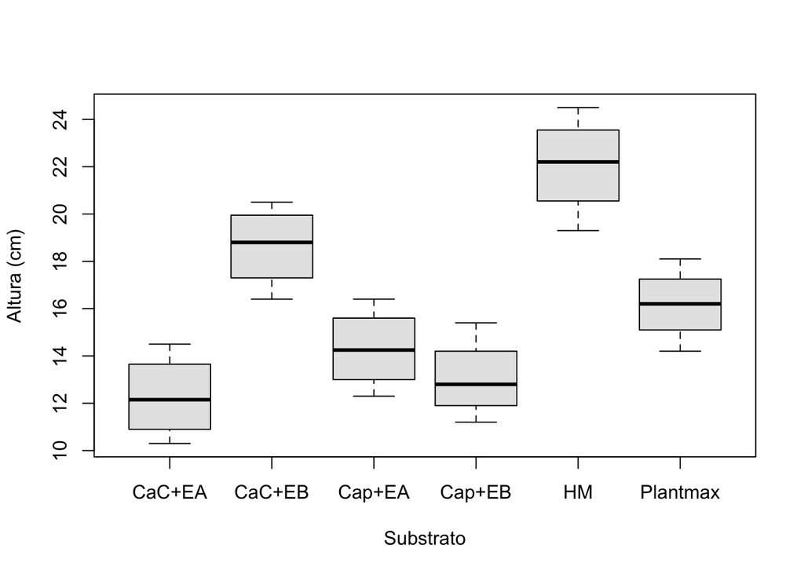

```r
boxplot(
  altura ~ substratos,
  data = dados_1,
  xlab = "Substrato",
  ylab = "Altura (cm)",
  col = "gray90"
)
```

```r
aggregate(
  altura ~ substratos,
  data = dados_1,
  FUN = function(x) c(
    n = length(x),
    media = mean(x),
    desvio_padrao = sd(x),
    mediana = median(x)
  )
)
```

```
  substratos  altura.n altura.media altura.desvio_padrao altura.mediana
1     CaC+EA  4.000000    12.275000             1.800694      12.150000
2     CaC+EB  4.000000    18.625000             1.755705      18.800000
3     Cap+EA  4.000000    14.300000             1.733974      14.250000
4     Cap+EB  4.000000    13.050000             1.746425      12.800000
5         HM  4.000000    22.050000             2.154840      22.200000
6   Plantmax  4.000000    16.175000             1.600781      16.200000
```

### Ajuste pela função `lm()`

```r
# Modelo linear do DIC
lm_dic <- lm(altura ~ substratos, data = dados_1)

# Estimativas dos parâmetros na parametrização padrão do R
summary(lm_dic)
```

```
Call:
lm(formula = altura ~ substratos, data = dados_1)

Residuals:
    Min      1Q  Median      3Q     Max
-2.7500 -1.0437 -0.1125  1.0500  2.4500

Coefficients:
                   Estimate Std. Error t value Pr(>|t|)
(Intercept)         12.2750     0.9034  13.587 6.66e-11 ***
substratosCaC+EB     6.3500     1.2776   4.970 9.90e-05 ***
substratosCap+EA     2.0250     1.2776   1.585  0.13038
substratosCap+EB     0.7750     1.2776   0.607  0.55169
substratosHM         9.7750     1.2776   7.651 4.60e-07 ***
substratosPlantmax   3.9000     1.2776   3.053  0.00685 **
---
Signif. codes:  0 '***' 0.001 '**' 0.01 '*' 0.05 '.' 0.1 ' ' 1

Residual standard error: 1.807 on 18 degrees of freedom
Multiple R-squared:  0.8244,    Adjusted R-squared:  0.7756
F-statistic:  16.9 on 5 and 18 DF,  p-value: 3.03e-06
```

```r
# Análise de variância
anova_dic <- anova(lm_dic)
anova_dic
```

```
Analysis of Variance Table

Response: altura
           Df  Sum Sq Mean Sq F value   Pr(>F)
substratos  5 275.817  55.163  16.898 3.03e-06 ***
Residuals  18  58.762   3.265
---
Signif. codes:  0 '***' 0.001 '**' 0.01 '*' 0.05 '.' 0.1 ' ' 1
```

Na tabela produzida por `anova()`:

- `Df` apresenta os graus de liberdade;
- `Sum Sq` apresenta as somas de quadrados;
- `Mean Sq` apresenta os quadrados médios;
- `F value` é a razão entre o quadrado médio do efeito e o quadrado médio residual;
- `Pr(>F)` é o valor-$p$ do teste.

O valor-$p$ é a probabilidade, sob $H_0$ e sob os pressupostos do modelo, de obter uma estatística tão extrema quanto a observada. Ele não é a probabilidade de $H_0$ ser verdadeira e não mede sozinho a importância prática do efeito.

O valor de $F$ compara a variação explicada pelos substratos com a variação entre repetições submetidas ao mesmo substrato. Neste exemplo, o teste global rejeita $H_0$ ($F=16{,}90$; valor-$p<0{,}001$).

Uma medida descritiva da proporção da variabilidade total associada ao fator é:

$$\eta^2=\frac{SQ_{Tratamentos}}{SQ_{Total}}.$$

```r
eta2_dic <- anova_dic["substratos", "Sum Sq"] / sum(anova_dic[, "Sum Sq"])
eta2_dic
```

```
[1] 0.8243691
```

O tamanho de efeito não substitui a estimativa das diferenças e seus intervalos de confiança, mas complementa o valor-$p$.

As médias ajustadas e seus intervalos de confiança também podem ser obtidos com o modelo. No DIC balanceado, elas coincidem com as médias aritméticas dos grupos.

```r
novos_substratos <- data.frame(
  substratos = factor(
    levels(dados_1$substratos),
    levels = levels(dados_1$substratos)
  )
)

intervalos_medias_dic <- cbind(
  novos_substratos,
  predict(
    lm_dic,
    newdata = novos_substratos,
    interval = "confidence",
    level = 1 - alfa
  )
)

intervalos_medias_dic
```

```
  substratos    fit      lwr      upr
1     CaC+EA 12.275 10.37701 14.17299
2     CaC+EB 18.625 16.72701 20.52299
3     Cap+EA 14.300 12.40201 16.19799
4     Cap+EB 13.050 11.15201 14.94799
5         HM 22.050 20.15201 23.94799
6   Plantmax 16.175 14.27701 18.07299
```

O coeficiente de variação experimental é uma medida relativa da dispersão residual:

$$CV(\%)=100\frac{\sqrt{QM_E}}{\bar{Y}_{\cdot\cdot}}.$$

```r
cv_dic <- 100 * sigma(lm_dic) / mean(dados_1$altura)
cv_dic
```

```
[1] 11.237
```

O CV deve ser comparado com referências da mesma variável, cultura, escala e condição experimental. Classificações universais como “baixo” ou “alto” podem ser enganosas. O CV também perde sentido quando a média está próxima de zero, pode mudar com a transformação e não deve ser comparado entre escalas distintas.

### Comparações múltiplas

O teste de Tukey controla a probabilidade de pelo menos um erro do tipo I no conjunto de todas as comparações duas a duas.

```r
aov_dic <- aov(altura ~ substratos, data = dados_1)
TukeyHSD(aov_dic, "substratos", conf.level = 1 - alfa)
```

```
  Tukey multiple comparisons of means
    95% family-wise confidence level

Fit: aov(formula = altura ~ substratos, data = dados_1)

$substratos
                  diff        lwr        upr     p adj
CaC+EB-CaC+EA    6.350  2.2897054 10.4102946 0.0011850
Cap+EA-CaC+EA    2.025 -2.0352946  6.0852946 0.6178206
Cap+EB-CaC+EA    0.775 -3.2852946  4.8352946 0.9891641
HM-CaC+EA        9.775  5.7147054 13.8352946 0.0000060
Plantmax-CaC+EA  3.900 -0.1602946  7.9602946 0.0639232
Cap+EA-CaC+EB   -4.325 -8.3852946 -0.2647054 0.0330224
Cap+EB-CaC+EB   -5.575 -9.6352946 -1.5147054 0.0042751
HM-CaC+EB        3.425 -0.6352946  7.4852946 0.1281603
Plantmax-CaC+EB -2.450 -6.5102946  1.6102946 0.4235416
Cap+EB-Cap+EA   -1.250 -5.3102946  2.8102946 0.9189774
HM-Cap+EA        7.750  3.6897054 11.8102946 0.0001241
Plantmax-Cap+EA  1.875 -2.1852946  5.9352946 0.6876671
HM-Cap+EB        9.000  4.9397054 13.0602946 0.0000185
Plantmax-Cap+EB  3.125 -0.9352946  7.1852946 0.1925714
Plantmax-HM     -5.875 -9.9352946 -1.8147054 0.0025987
```

O pacote `ExpDes` apresenta a ANOVA e o agrupamento de médias em uma única rotina.

```r
crd(
  treat = dados_1$substratos,
  resp = dados_1$altura,
  mcomp = "tukey"
)
```

```
------------------------------------------------------------------------
Analysis of Variance Table
------------------------------------------------------------------------
           DF     SS     MS     Fc      Pr>Fc
Treatament  5 275.82 55.163 16.898 3.0304e-06
Residuals  18  58.76  3.265
Total      23 334.58
------------------------------------------------------------------------
CV = 11.24 %

------------------------------------------------------------------------
Shapiro-Wilk normality test
p-value:  0.1502373
According to Shapiro-Wilk normality test at 5% of significance, residuals can be considered normal.
------------------------------------------------------------------------

------------------------------------------------------------------------
Homogeneity of variances test
p-value:  0.9980527
According to the test of bartlett at 5% of significance, residuals can be considered homocedastic.
------------------------------------------------------------------------

Tukey's test
------------------------------------------------------------------------
Groups Treatments Means
a    HM      22.05
ab   CaC+EB      18.625
 bc      Plantmax    16.175
  c      Cap+EA      14.3
  c      Cap+EB      13.05
  c      CaC+EA      12.275
------------------------------------------------------------------------
```

Quando houver interesse no método de agrupamento Scott–Knott:

```r
crd(
  treat = dados_1$substratos,
  resp = dados_1$altura,
  mcomp = "sk"
)
```

```
------------------------------------------------------------------------
Analysis of Variance Table
------------------------------------------------------------------------
           DF     SS     MS     Fc      Pr>Fc
Treatament  5 275.82 55.163 16.898 3.0304e-06
Residuals  18  58.76  3.265
Total      23 334.58
------------------------------------------------------------------------
CV = 11.24 %

------------------------------------------------------------------------
Shapiro-Wilk normality test
p-value:  0.1502373
According to Shapiro-Wilk normality test at 5% of significance, residuals can be considered normal.
------------------------------------------------------------------------

------------------------------------------------------------------------
Homogeneity of variances test
p-value:  0.9980527
According to the test of bartlett at 5% of significance, residuals can be considered homocedastic.
------------------------------------------------------------------------

Scott-Knott test
------------------------------------------------------------------------
  Groups Treatments  Means
1      a         HM 22.050
2      b     CaC+EB 18.625
3      c   Plantmax 16.175
4      c     Cap+EA 14.300
5      c     Cap+EB 13.050
6      c     CaC+EA 12.275
------------------------------------------------------------------------
```

Os procedimentos respondem a perguntas diferentes. Tukey testa todas as diferenças duas a duas; Scott–Knott procura formar grupos de médias. A escolha deve ser definida pelo objetivo da análise e, preferencialmente, antes de olhar os resultados.

## Delineamento em blocos casualizados

O **delineamento em blocos casualizados (DBC)** é indicado quando existe uma fonte conhecida de heterogeneidade. Cada bloco contém todos os tratamentos e a casualização é feita separadamente dentro de cada bloco.

O modelo é:

$$Y_{ij}=\mu+\tau_i+\beta_j+\varepsilon_{ij},$$

em que $\tau_i$ é o efeito do tratamento $i$ e $\beta_j$ é o efeito do bloco $j$. Adotam-se, por exemplo, as restrições:

$$\sum_{i=1}^{a}\tau_i=0
\qquad\text{e}\qquad
\sum_{j=1}^{b}\beta_j=0.$$

O modelo é aditivo: não há termo tratamento $\times$ bloco. Com uma observação por combinação, essa interação não pode ser separada do erro. Por isso, a resposta relativa dos tratamentos deve ser aproximadamente consistente entre os blocos.

Nos exemplos deste material, tratamentos representam níveis específicos de interesse e são tratados como efeitos fixos. Blocos podem ser considerados fixos quando o interesse se restringe aos blocos observados, ou aleatórios quando representam uma população de condições. Em um DBC completo e balanceado, o teste dos tratamentos baseado no erro intrablocos coincide nas formulações usuais de efeitos fixos ou aleatórios. Com dados ausentes, estruturas hierárquicas ou interesse em componentes de variância, um modelo misto deve representar explicitamente a natureza aleatória dos blocos.

Para o DBC completo e balanceado:

$$SQ_{Total}=SQ_{Tratamentos}+SQ_{Blocos}+SQ_{Erro}.$$

| Fonte de variação | Graus de liberdade | Estatística $F$ |
| --- | --- | --- |
| Tratamentos | $a-1$ | $QM_{Trat}/QM_E$ |
| Blocos | $b-1$ | $QM_{Blocos}/QM_E$ |
| Erro | $(a-1)(b-1)$ |  |
| Total | $ab-1$ |  |

O teste dos blocos é secundário. O bloco é uma ferramenta de controle local e não o foco do estudo. A utilidade do bloqueamento deve ser avaliada também pela redução do quadrado médio do erro e pelo conhecimento do experimento.

### Planejamento e casualização no DBC

Um bom bloco é internamente homogêneo e pode ser diferente dos demais blocos. Exemplos de critérios de blocagem incluem fertilidade do solo, declividade, peso inicial, lote de matéria-prima, dia, operador ou avaliador.

Com $a$ tratamentos e $b$ blocos, há $(a!)^b$ possíveis alocações quando uma permutação independente é sorteada em cada bloco.

```r
set.seed(2026)

tratamentos_dbc <- c("A", "B", "C", "D")

plano_dbc <- do.call(
  rbind,
  lapply(1:6, function(j) {
    data.frame(
      bloco = factor(j),
      parcela_no_bloco = 1:4,
      tratamento = sample(tratamentos_dbc)
    )
  })
)

plano_dbc
```

```
   bloco parcela_no_bloco tratamento
1      1                1          A
2      1                2          D
3      1                3          C
4      1                4          B
5      2                1          A
6      2                2          C
7      2                3          D
8      2                4          B
9      3                1          D
10     3                2          A
11     3                3          C
12     3                4          B
13     4                1          B
14     4                2          D
15     4                3          C
16     4                4          A
17     5                1          C
18     5                2          A
19     5                3          B
20     5                4          D
21     6                1          D
22     6                2          B
23     6                3          C
24     6                4          A
```

### Experimento 2: épocas de corte da alfafa

O experimento avalia quatro épocas de corte, $A$, $B$, $C$ e $D$, na produtividade de matéria verde de alfafa. Foram formados seis blocos para controlar um gradiente de fertilidade associado à declividade da área.

| Bloco | $A$ | $B$ | $C$ | $D$ |
| --- | --- | --- | --- | --- |
| I | 2,89 | 1,58 | 2,29 | 2,56 |
| II | 2,88 | 1,28 | 2,98 | 2,00 |
| III | 1,88 | 1,22 | 1,55 | 1,82 |
| IV | 2,90 | 1,21 | 1,95 | 2,20 |
| V | 2,20 | 1,30 | 1,15 | 1,33 |
| VI | 2,65 | 1,66 | 1,12 | 1,00 |

Os valores representam a produção de matéria verde em kg/parcela.

Arquivo com os dados: dados_2.xlsx

```r
dados_2 <- read_xlsx("dados_2.xlsx")
dados_2$bloco <- factor(dados_2$bloco)
dados_2$epoca <- factor(dados_2$epoca)

str(dados_2)
```

```
tibble [24 × 3] (S3: tbl_df/tbl/data.frame)
 $ bloco        : Factor w/ 6 levels "1","2","3","4",..: 1 1 1 1 2 2 2 2 3 3 ...
 $ epoca        : Factor w/ 4 levels "A","B","C","D": 1 2 3 4 1 2 3 4 1 2 ...
 $ produtividade: num [1:24] 2.89 1.58 2.29 2.56 2.88 1.28 2.98 2 1.88 1.22 ...
```

```r
aggregate(
  produtividade ~ epoca,
  data = dados_2,
  FUN = function(x) c(media = mean(x), desvio_padrao = sd(x))
)
```

```
  epoca produtividade.media produtividade.desvio_padrao
1     A           2.5666667                   0.4305191
2     B           1.3750000                   0.1944994
3     C           1.8400000                   0.7201111
4     D           1.8183333                   0.5721684
```

### Ajuste do DBC

```r
lm_dbc <- lm(produtividade ~ bloco + epoca, data = dados_2)

summary(lm_dbc)
```

```
Call:
lm(formula = produtividade ~ bloco + epoca, data = dados_2)

Residuals:
     Min       1Q   Median       3Q      Max
-0.52583 -0.24000 -0.03125  0.23354  0.75500

Coefficients:
            Estimate Std. Error t value Pr(>|t|)
(Intercept)   2.9967     0.2543  11.784 5.54e-09 ***
bloco2       -0.0450     0.2936  -0.153 0.880242
bloco3       -0.7125     0.2936  -2.426 0.028318 *
bloco4       -0.2650     0.2936  -0.902 0.381063
bloco5       -0.8350     0.2936  -2.844 0.012323 *
bloco6       -0.7225     0.2936  -2.461 0.026486 *
epocaB       -1.1917     0.2397  -4.970 0.000168 ***
epocaC       -0.7267     0.2397  -3.031 0.008425 **
epocaD       -0.7483     0.2397  -3.121 0.007006 **
---
Signif. codes:  0 '***' 0.001 '**' 0.01 '*' 0.05 '.' 0.1 ' ' 1

Residual standard error: 0.4153 on 15 degrees of freedom
Multiple R-squared:  0.7341,    Adjusted R-squared:  0.5923
F-statistic: 5.176 on 8 and 15 DF,  p-value: 0.003083
```

```r
anova_dbc <- anova(lm_dbc)
anova_dbc
```

```
Analysis of Variance Table

Response: produtividade
          Df Sum Sq Mean Sq F value   Pr(>F)
bloco      5 2.7590 0.55179  3.1999 0.036559 *
epoca      3 4.3820 1.46068  8.4706 0.001572 **
Residuals 15 2.5866 0.17244
---
Signif. codes:  0 '***' 0.001 '**' 0.01 '*' 0.05 '.' 0.1 ' ' 1
```

O teste de tratamentos indica diferença entre as épocas ($F=8{,}47$; valor-$p=0{,}0016$). O efeito de blocos também é detectável, o que é coerente com a presença do gradiente usado para formar os blocos.

```r
aov_dbc <- aov(produtividade ~ bloco + epoca, data = dados_2)
TukeyHSD(aov_dbc, "epoca", conf.level = 1 - alfa)
```

```
  Tukey multiple comparisons of means
    95% family-wise confidence level

Fit: aov(formula = produtividade ~ bloco + epoca, data = dados_2)

$epoca
           diff        lwr         upr     p adj
B-A -1.19166667 -1.8826637 -0.50066968 0.0008626
C-A -0.72666667 -1.4176637 -0.03566968 0.0377333
D-A -0.74833333 -1.4393303 -0.05733634 0.0317423
C-B  0.46500000 -0.2259970  1.15599699 0.2537403
D-B  0.44333333 -0.2476637  1.13433032 0.2900919
D-C -0.02166667 -0.7126637  0.66933032 0.9997229
```

```r
rbd(
  treat = dados_2$epoca,
  block = dados_2$bloco,
  resp = dados_2$produtividade,
  mcomp = "tukey"
)
```

```
------------------------------------------------------------------------
Analysis of Variance Table
------------------------------------------------------------------------
           DF     SS      MS     Fc    Pr>Fc
Treatament  3 4.3820 1.46068 8.4706 0.001572
Block       5 2.7590 0.55179 3.1999 0.036559
Residuals  15 2.5866 0.17244
Total      23 9.7276
------------------------------------------------------------------------
CV = 21.86 %

------------------------------------------------------------------------
Shapiro-Wilk normality test
p-value:  0.7947678
According to Shapiro-Wilk normality test at 5% of significance, residuals can be considered normal.
------------------------------------------------------------------------

------------------------------------------------------------------------
Homogeneity of variances test
p-value:  0.6274363
According to the test of oneillmathews at 5% of significance, the variances can be considered homocedastic.
------------------------------------------------------------------------

Tukey's test
------------------------------------------------------------------------
Groups Treatments Means
a    A   2.566667
 b   C   1.84
 b   D   1.818333
 b   B   1.375
------------------------------------------------------------------------
```

O teste de Duncan é apresentado apenas para mostrar a sintaxe disponível no pacote. Ele é menos conservador que Tukey e pode aumentar o risco de resultados falso-positivos quando muitas médias são comparadas.

```r
rbd(
  treat = dados_2$epoca,
  block = dados_2$bloco,
  resp = dados_2$produtividade,
  mcomp = "duncan"
)
```

```
------------------------------------------------------------------------
Analysis of Variance Table
------------------------------------------------------------------------
           DF     SS      MS     Fc    Pr>Fc
Treatament  3 4.3820 1.46068 8.4706 0.001572
Block       5 2.7590 0.55179 3.1999 0.036559
Residuals  15 2.5866 0.17244
Total      23 9.7276
------------------------------------------------------------------------
CV = 21.86 %

------------------------------------------------------------------------
Shapiro-Wilk normality test
p-value:  0.7947678
According to Shapiro-Wilk normality test at 5% of significance, residuals can be considered normal.
------------------------------------------------------------------------

------------------------------------------------------------------------
Homogeneity of variances test
p-value:  0.6274363
According to the test of oneillmathews at 5% of significance, the variances can be considered homocedastic.
------------------------------------------------------------------------

Duncan's test
------------------------------------------------------------------------
Groups  Treatments  Means
a    A       2.566667
 b   C       1.84
 b   D       1.818333
 b   B       1.375
------------------------------------------------------------------------
```

### Eficiência do bloqueamento

Uma comparação descritiva consiste em confrontar o quadrado médio residual do modelo que ignora os blocos com o quadrado médio residual do DBC:

$$ER(\%)=100\frac{QM_{E,\,DIC}}{QM_{E,\,DBC}}.$$

```r
lm_sem_blocos <- lm(produtividade ~ epoca, data = dados_2)

qm_erro_sem_blocos <- anova(lm_sem_blocos)["Residuals", "Mean Sq"]
qm_erro_dbc <- anova_dbc["Residuals", "Mean Sq"]

eficiencia_relativa <- 100 * qm_erro_sem_blocos / qm_erro_dbc
eficiencia_relativa
```

```
[1] 154.9969
```

Neste conjunto, a razão é aproximadamente $155\%$. Essa medida é uma descrição dos dados observados e não autoriza escolher o delineamento depois da coleta. O DBC deve ser definido no planejamento e analisado como foi casualizado.

## Delineamento em quadrado latino

O **delineamento em quadrado latino (DQL)** controla duas fontes de heterogeneidade, representadas por linhas e colunas. Se há $p$ tratamentos, o experimento deve ter $p$ linhas, $p$ colunas e $p^2$ observações. Cada tratamento aparece uma vez em cada linha e uma vez em cada coluna.

O modelo aditivo é:

$$Y_{ijk}=\mu+\rho_i+\kappa_j+\tau_k+\varepsilon_{ijk},$$

em que $\rho_i$ é o efeito da linha, $\kappa_j$ é o efeito da coluna e $\tau_k$ é o efeito do tratamento. Como o tratamento aplicado a cada célula é determinado pelo quadrado latino, linha e coluna localizam a observação.

Adotam-se as restrições:

$$\sum_i\rho_i=0,\qquad
\sum_j\kappa_j=0,\qquad
\sum_k\tau_k=0.$$

| Fonte de variação | Graus de liberdade | Estatística $F$ |
| --- | --- | --- |
| Linhas | $p-1$ | $QM_L/QM_E$ |
| Colunas | $p-1$ | $QM_C/QM_E$ |
| Tratamentos | $p-1$ | $QM_{Trat}/QM_E$ |
| Erro | $(p-1)(p-2)$ |  |
| Total | $p^2-1$ |  |

O DQL fornece poucos graus de liberdade residuais quando $p$ é pequeno. Além disso, o modelo supõe aditividade: não há graus de liberdade para estimar as interações tratamento $\times$ linha ou tratamento $\times$ coluna. Essa limitação deve ser considerada no planejamento e na interpretação.

### Casualização no DQL

Não se sorteiam os tratamentos independentemente nas $p^2$ células, pois isso destruiria a estrutura latina. Parte-se de um quadrado válido e realizam-se, de forma aleatória:

1. uma permutação das linhas;
2. uma permutação das colunas;
3. uma permutação dos rótulos dos tratamentos;
4. opcionalmente, uma transposição do quadrado.

```r
set.seed(2026)

p <- 5
quadrado_base <- outer(0:(p - 1), 0:(p - 1), function(i, j) {
  LETTERS[(i + j) %% p + 1]
})

ordem_linhas <- sample(1:p)
ordem_colunas <- sample(1:p)
novos_rotulos <- sample(LETTERS[1:p])

quadrado_dql <- quadrado_base[ordem_linhas, ordem_colunas]
quadrado_dql <- matrix(
  novos_rotulos[match(quadrado_dql, LETTERS[1:p])],
  nrow = p
)

quadrado_dql
```

```
     [,1] [,2] [,3] [,4] [,5]
[1,] "E"  "C"  "D"  "A"  "B"
[2,] "C"  "A"  "B"  "D"  "E"
[3,] "B"  "E"  "A"  "C"  "D"
[4,] "A"  "D"  "E"  "B"  "C"
[5,] "D"  "B"  "C"  "E"  "A"
```

### Experimento 3: formulações de um propulsor

Um engenheiro estuda cinco formulações de um propulsor. Os lotes de matéria-prima constituem as linhas e os operadores constituem as colunas. Cada formulação é avaliada uma vez em cada lote e uma vez por cada operador.

| Lote/Operador | 1 | 2 | 3 | 4 | 5 |
| --- | --- | --- | --- | --- | --- |
| 1 | A=24 | B=20 | C=19 | D=24 | E=24 |
| 2 | B=17 | C=24 | D=30 | E=27 | A=36 |
| 3 | C=18 | D=38 | E=26 | A=27 | B=21 |
| 4 | D=26 | E=31 | A=26 | B=23 | C=22 |
| 5 | E=22 | A=30 | B=20 | C=29 | D=31 |

Arquivo com os dados: dados_3.xlsx

```r
dados_3 <- read_xlsx("dados_3.xlsx")
dados_3$lote <- factor(dados_3$lote)
dados_3$operador <- factor(dados_3$operador)
dados_3$formulacoes <- factor(dados_3$formulacoes)

str(dados_3)
```

```
tibble [25 × 4] (S3: tbl_df/tbl/data.frame)
 $ lote       : Factor w/ 5 levels "1","2","3","4",..: 1 2 3 4 5 1 2 3 4 5 ...
 $ operador   : Factor w/ 5 levels "1","2","3","4",..: 1 1 1 1 1 2 2 2 2 2 ...
 $ formulacoes: Factor w/ 5 levels "A","B","C","D",..: 1 2 3 4 5 2 3 4 5 1 ...
 $ velocidade : num [1:25] 24 17 18 26 22 20 24 38 31 30 ...
```

```r
# Cada formulação deve aparecer uma vez em cada lote e em cada operador
xtabs(~ lote + formulacoes, data = dados_3)
```

```
    formulacoes
lote A B C D E
   1 1 1 1 1 1
   2 1 1 1 1 1
   3 1 1 1 1 1
   4 1 1 1 1 1
   5 1 1 1 1 1
```

```r
xtabs(~ operador + formulacoes, data = dados_3)
```

```
        formulacoes
operador A B C D E
       1 1 1 1 1 1
       2 1 1 1 1 1
       3 1 1 1 1 1
       4 1 1 1 1 1
       5 1 1 1 1 1
```

### Ajuste do DQL

```r
lm_dql <- lm(
  velocidade ~ lote + operador + formulacoes,
  data = dados_3
)

summary(lm_dql)
```

```
Call:
lm(formula = velocidade ~ lote + operador + formulacoes, data = dados_3)

Residuals:
   Min     1Q Median     3Q    Max
  -3.2   -1.2   -0.2    1.0    5.0

Coefficients:
             Estimate Std. Error t value Pr(>|t|)
(Intercept)    21.400      2.355   9.087 9.98e-07 ***
lote2           4.600      2.066   2.227  0.04586 *
lote3           3.800      2.066   1.840  0.09067 .
lote4           3.400      2.066   1.646  0.12568
lote5           4.200      2.066   2.033  0.06475 .
operador2       7.200      2.066   3.486  0.00450 **
operador3       2.800      2.066   1.356  0.20021
operador4       4.600      2.066   2.227  0.04586 *
operador5       5.400      2.066   2.614  0.02262 *
formulacoesB   -8.400      2.066  -4.067  0.00156 **
formulacoesC   -6.200      2.066  -3.002  0.01103 *
formulacoesD    1.200      2.066   0.581  0.57203
formulacoesE   -2.600      2.066  -1.259  0.23207
---
Signif. codes:  0 '***' 0.001 '**' 0.01 '*' 0.05 '.' 0.1 ' ' 1

Residual standard error: 3.266 on 12 degrees of freedom
Multiple R-squared:  0.8107,    Adjusted R-squared:  0.6213
F-statistic: 4.281 on 12 and 12 DF,  p-value: 0.008855
```

```r
anova_dql <- anova(lm_dql)
anova_dql
```

```
Analysis of Variance Table

Response: velocidade
            Df Sum Sq Mean Sq F value   Pr(>F)
lote         4     68  17.000  1.5938 0.239059
operador     4    150  37.500  3.5156 0.040373 *
formulacoes  4    330  82.500  7.7344 0.002537 **
Residuals   12    128  10.667
---
Signif. codes:  0 '***' 0.001 '**' 0.01 '*' 0.05 '.' 0.1 ' ' 1
```

O efeito das formulações é significativo ($F=7{,}73$; valor-$p=0{,}0025$), após controlar as diferenças entre lotes e entre operadores. Neste exemplo, operadores também explicam uma parcela relevante da variação, enquanto o efeito de lotes não é detectável ao nível de $5\%$.

```r
aov_dql <- aov(
  velocidade ~ lote + operador + formulacoes,
  data = dados_3
)

TukeyHSD(aov_dql, "formulacoes", conf.level = 1 - alfa)
```

```
  Tukey multiple comparisons of means
    95% family-wise confidence level

Fit: aov(formula = velocidade ~ lote + operador + formulacoes, data = dados_3)

$formulacoes
    diff         lwr        upr     p adj
B-A -8.4 -14.9839317 -1.8160683 0.0110827
C-A -6.2 -12.7839317  0.3839317 0.0684350
D-A  1.2  -5.3839317  7.7839317 0.9754380
E-A -2.6  -9.1839317  3.9839317 0.7194121
C-B  2.2  -4.3839317  8.7839317 0.8204614
D-B  9.6   3.0160683 16.1839317 0.0041583
E-B  5.8  -0.7839317 12.3839317 0.0944061
D-C  7.4   0.8160683 13.9839317 0.0254304
E-C  3.6  -2.9839317 10.1839317 0.4461852
E-D -3.8 -10.3839317  2.7839317 0.3966727
```

```r
latsd(
  treat = dados_3$formulacoes,
  row = dados_3$lote,
  column = dados_3$operador,
  resp = dados_3$velocidade,
  mcomp = "tukey"
)
```

```
------------------------------------------------------------------------
Analysis of Variance Table
------------------------------------------------------------------------
           DF  SS     MS     Fc    Pr>Fc
Treatament  4 330 82.500 7.7344 0.002537
Row         4  68 17.000 1.5938 0.239059
Column      4 150 37.500 3.5156 0.040373
Residuals  12 128 10.667
Total      24 676
------------------------------------------------------------------------
CV = 12.86 %

------------------------------------------------------------------------
Shapiro-Wilk normality test
p-value:  0.05810583
According to Shapiro-Wilk normality test at 5% of significance, residuals can be considered normal.
------------------------------------------------------------------------

Tukey's test
------------------------------------------------------------------------
Groups Treatments Means
a    D   29.8
ab   A   28.6
abc      E   26
 bc      C   22.4
  c      B   20.2
------------------------------------------------------------------------
```

### Dados ausentes e desbalanceamento

As fórmulas clássicas apresentadas pressupõem dados completos e balanceados. Em um DIC, números diferentes de repetições ainda podem ser analisados por modelo linear, mas as médias têm precisões diferentes e a ordem dos termos pode importar em modelos com vários fatores não ortogonais.

No DBC, uma parcela perdida quebra a ortogonalidade entre tratamentos e blocos. No DQL, a perda de uma única observação é particularmente séria porque o delineamento já possui poucos graus de liberdade residuais. Nesses casos:

- não preencha o valor ausente pela média antes de ajustar o modelo;
- registre a causa da perda e verifique se ela pode depender do tratamento;
- use o modelo linear com os dados observados e métodos de somas de quadrados apropriados à hipótese;
- ajuste os graus de liberdade e as comparações de médias;
- não use rotinas que pressupõem balanceamento sem verificar seu comportamento;
- apresente uma análise de sensibilidade quando o mecanismo de ausência for duvidoso.

Em situações não ortogonais, os testes sequenciais de `anova(lm(...))` dependem da ordem dos termos. A hipótese científica deve ser definida antes da escolha de somas de quadrados do tipo I, II ou III. O balanceamento planejado continua sendo a forma mais simples de preservar precisão e interpretação.

# Análise de resíduos

A validade da ANOVA depende do modelo, do delineamento e do mecanismo de casualização. Os principais pressupostos sobre os erros são:

1. média zero;
2. independência;
3. variância constante;
4. distribuição aproximadamente normal para a inferência exata em pequenas amostras;
5. aditividade e especificação correta do modelo.

O diagnóstico deve ser realizado **depois do ajuste** e com os resíduos. Testar a normalidade separadamente em cada tratamento, com apenas três ou quatro observações, tem pouca utilidade.

## Tipos de resíduos

O resíduo bruto é:

$$e_i=Y_i-\widehat{Y}_i.$$

O resíduo de Pearson no modelo linear homocedástico é:

$$d_i=\frac{e_i}{\widehat{\sigma}}.$$

Como a variância de $e_i$ depende da alavancagem $h_{ii}$, o resíduo studentizado internamente é:

$$r_i=\frac{e_i}{\widehat{\sigma}\sqrt{1-h_{ii}}}.$$

O resíduo studentizado externamente usa uma estimativa de $\sigma$ calculada sem a observação $i$ e é especialmente útil para investigar valores discrepantes.

```r
diagnostico_dic <- data.frame(
  observado = dados_1$altura,
  ajustado = fitted(lm_dic),
  residuo_bruto = residuals(lm_dic),
  residuo_pearson = residuals(lm_dic) / sigma(lm_dic),
  residuo_padronizado = rstandard(lm_dic),
  residuo_studentizado = rstudent(lm_dic),
  alavancagem = hatvalues(lm_dic),
  distancia_cook = cooks.distance(lm_dic)
)

diagnostico_dic
```

```
   observado ajustado residuo_bruto residuo_pearson residuo_padronizado
1       18.2   18.625        -0.425     -0.23522044         -0.27160916
2       16.4   18.625        -2.225     -1.23144816         -1.42195386
3       20.5   18.625         1.875      1.03773722          1.19827572
4       19.4   18.625         0.775      0.42893138          0.49528730
5       12.8   12.275         0.525      0.29056642          0.33551720
6       14.5   12.275         2.225      1.23144816          1.42195386
7       10.3   12.275        -1.975     -1.09308320         -1.26218376
8       11.5   12.275        -0.775     -0.42893138         -0.49528730
9       21.8   22.050        -0.250     -0.13836496         -0.15977010
10      19.3   22.050        -2.750     -1.52201459         -1.75747106
11      24.5   22.050         2.450      1.35597663          1.56574695
12      22.6   22.050         0.550      0.30440292          0.35149421
13      14.8   14.300         0.500      0.27672992          0.31954019
14      16.4   14.300         2.100      1.16226568          1.34206881
```

[output cut: 35 more lines]

No DIC balanceado, as alavancagens são iguais dentro da estrutura do modelo. Em experimentos desbalanceados ou com covariáveis, elas podem variar de forma importante.

## Sequência recomendada de diagnóstico

- Conferir a digitação, as unidades de medida e os níveis dos fatores.
- Verificar se o modelo reproduz o delineamento usado na casualização.
- Examinar resíduos versus valores ajustados.
- Examinar resíduos por tratamento e, quando aplicável, por bloco.
- Construir o gráfico quantil-quantil dos resíduos.
- Examinar resíduos na ordem real de execução ou coleta.
- Investigar observações influentes nos registros experimentais.
- Somente então considerar transformação, outro modelo ou método robusto.

## Normalidade dos resíduos

O histograma pode auxiliar, mas é pouco informativo em amostras pequenas. O gráfico quantil-quantil costuma ser mais útil.

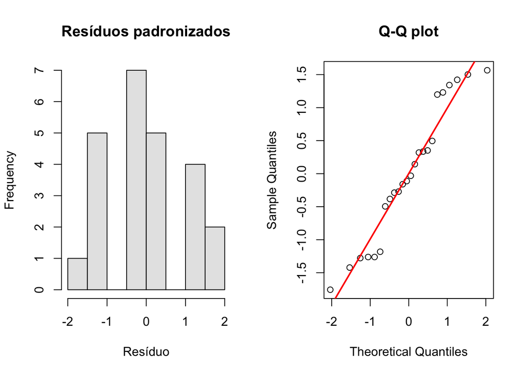

```r
res_dic <- rstandard(lm_dic)

par(mfrow = c(1, 2))
hist(
  res_dic,
  main = "Resíduos padronizados",
  xlab = "Resíduo",
  col = "gray90"
)
qqnorm(res_dic, main = "Q-Q plot")
qqline(res_dic, col = "red", lwd = 2)
```

```r
par(mfrow = c(1, 1))
```

Uma verificação descritiva compara as frequências observadas em intervalos da normal padrão. Com poucos resíduos, desvios das proporções teóricas são naturais.

```r
intervalos <- c("-1 a 1", "-1,64 a 1,64", "-1,96 a 1,96")

frequencias_observadas <- c(
  mean(abs(res_dic) < 1),
  mean(abs(res_dic) < 1.64),
  mean(abs(res_dic) < 1.96)
)

data.frame(
  intervalo = intervalos,
  frequencia_observada = frequencias_observadas,
  probabilidade_normal = c(0.68, 0.90, 0.95)
)
```

```
     intervalo frequencia_observada probabilidade_normal
1       -1 a 1            0.5000000                 0.68
2 -1,64 a 1,64            0.9583333                 0.90
3 -1,96 a 1,96            1.0000000                 0.95
```

O teste de Shapiro–Wilk avalia a compatibilidade com a normalidade:

```r
shapiro.test(res_dic)
```

```
    Shapiro-Wilk normality test

data:  res_dic
W = 0.9384, p-value = 0.1502
```

Não rejeitar $H_0$ não prova normalidade. Em amostras pequenas, o teste tem baixa potência; em amostras grandes, desvios pouco relevantes podem ser detectados. Gráficos, delineamento, equilíbrio dos tamanhos amostrais e sensibilidade das conclusões devem ser considerados conjuntamente.

O teste de Kolmogorov–Smirnov usual não deve ser aplicado como se os parâmetros da normal fossem conhecidos quando média e variância foram estimadas com os próprios resíduos. Nessa situação, a distribuição de referência muda. Além disso, os resíduos não são uma amostra independente comum, pois satisfazem restrições impostas pelo ajuste.

## Independência

Independência é principalmente uma consequência do planejamento. Repetições devem ser unidades experimentais distintas, e a casualização deve impedir que tratamentos fiquem confundidos com tempo, posição, operador ou lote.

Quando a ordem de execução é conhecida:

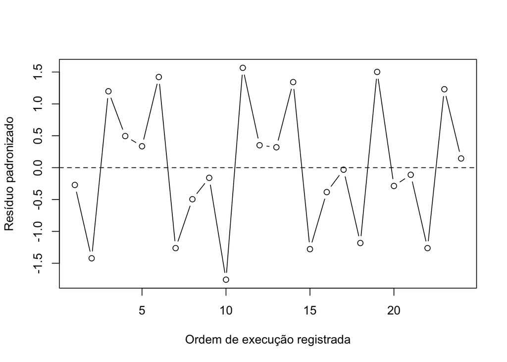

```r
ordem_execucao <- seq_along(res_dic)

plot(
  ordem_execucao,
  res_dic,
  type = "b",
  xlab = "Ordem de execução registrada",
  ylab = "Resíduo padronizado"
)
abline(h = 0, lty = 2)
```

*No exemplo, a ordem no arquivo não foi informada como ordem real de execução; portanto, o gráfico é apenas uma demonstração de código. Testes como Durbin–Watson, Breusch–Godfrey e Ljung–Box só fazem sentido quando existe uma ordem temporal ou espacial relevante. Nenhum teste corrige pseudorrepetição.*

## Homogeneidade de variâncias

O primeiro diagnóstico é o gráfico de resíduos versus valores ajustados. Um formato de funil sugere que a variabilidade depende da média.

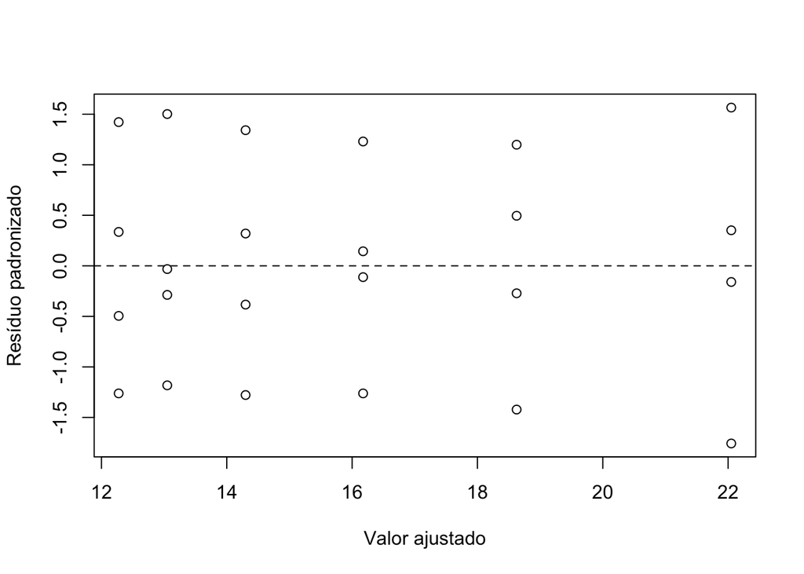

```r
plot(
  fitted(lm_dic),
  res_dic,
  xlab = "Valor ajustado",
  ylab = "Resíduo padronizado"
)
abline(h = 0, lty = 2)
```

Também é útil comparar a dispersão em cada tratamento:

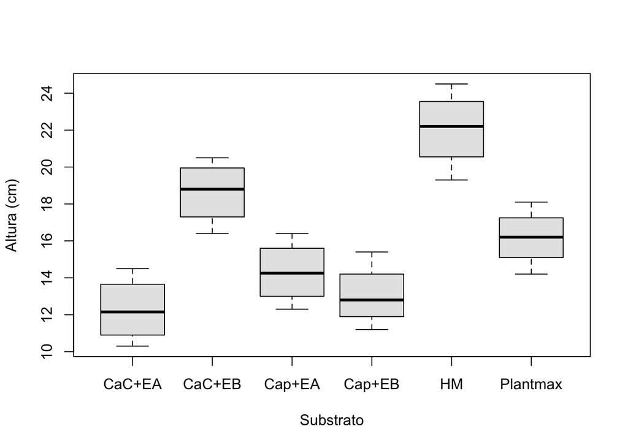

```r
boxplot(
  altura ~ substratos,
  data = dados_1,
  xlab = "Substrato",
  ylab = "Altura (cm)",
  col = "gray90"
)
```

O teste de Bartlett é eficiente sob normalidade, mas muito sensível a desvios desse pressuposto:

```r
bartlett.test(altura ~ substratos, data = dados_1)
```

```
    Bartlett test of homogeneity of variances

data:  altura by substratos
Bartlett's K-squared = 0.27704, df = 5, p-value = 0.9981
```

Uma versão do teste de Levene centrada nas medianas pode ser construída com funções básicas do R:

```r
mediana_grupo <- ave(
  dados_1$altura,
  dados_1$substratos,
  FUN = median
)

desvio_absoluto <- abs(dados_1$altura - mediana_grupo)
anova(lm(desvio_absoluto ~ dados_1$substratos))
```

```
Analysis of Variance Table

Response: desvio_absoluto
                   Df  Sum Sq Mean Sq F value Pr(>F)
dados_1$substratos  5  0.4737 0.09475  0.0896 0.9929
Residuals          18 19.0425 1.05792
```

ou usando a função `leveneTest()` do pacote `car`:

```r
library(car)
leveneTest(altura ~ substratos, data = dados_1, center = median)
```

```
Levene's Test for Homogeneity of Variance (center = median)
      Df F value Pr(>F)
group  5  0.0896 0.9929
      18
```

O teste de Breusch–Pagan avalia se a variância está associada aos preditores do modelo:

```r
bptest(lm_dic)
```

```
    studentized Breusch-Pagan test

data:  lm_dic
BP = 1.0259, df = 5, p-value = 0.9605
```

Resultados de testes de variância devem ser interpretados com os gráficos. Em um DIC balanceado, a ANOVA costuma ser relativamente robusta a heterogeneidade moderada; a situação é mais preocupante com forte desigualdade e tamanhos amostrais diferentes.

## Robustez da ANOVA

Robustez não significa ausência de pressupostos. Em delineamentos balanceados, o teste $F$ costuma tolerar assimetria moderada e pequenas diferenças de variância, especialmente quando há número razoável de repetições. A preocupação aumenta quando ocorrem simultaneamente:

- poucas repetições;
- forte assimetria ou caudas pesadas;
- valores extremos influentes;
- razão muito grande entre as variâncias dos grupos;
- desbalanceamento associado às variâncias;
- dependência entre unidades.

Normalidade e homocedasticidade se referem à distribuição condicional dos erros. Não se deve abandonar automaticamente a ANOVA por um único teste de diagnóstico com valor-$p$ ligeiramente inferior a $0{,}05$. É mais informativo comparar a conclusão paramétrica com uma transformação, um método robusto ou um teste de randomização que preserve o delineamento.

## Pontos discrepantes e influência

Um valor extremo não deve ser excluído automaticamente. Primeiro é necessário verificar erro de digitação, falha de equipamento, troca de tratamento ou uma resposta biologicamente legítima.

```r
limite_cook <- 4 / nrow(dados_1)

subset(
  diagnostico_dic,
  abs(residuo_studentizado) > 2 | distancia_cook > limite_cook
)
```

```
   observado ajustado residuo_bruto residuo_pearson residuo_padronizado
10      19.3    22.05         -2.75       -1.522015           -1.757471
   residuo_studentizado alavancagem distancia_cook
10            -1.876528        0.25      0.1715947
```

Os limites $|r_i|>2$ e $D_i>4/n$ são regras de triagem, não testes automáticos de exclusão. Uma análise de sensibilidade, com e sem a observação justificada, pode mostrar se a conclusão depende de um único ponto.

## Aditividade e especificação do modelo

Quando o tratamento é categórico, não existe uma exigência de “linearidade da resposta em relação ao tratamento” como haveria para uma covariável contínua. A questão correta é se a estrutura aditiva do modelo é adequada.

No DBC e no DQL, interações com blocos, linhas ou colunas não são estimadas com uma observação por célula. Perfis muito cruzados, padrões espaciais ou resíduos sistemáticos podem indicar não aditividade. A solução pode envolver outro delineamento, repetição dentro das células, covariáveis, modelos mistos ou uma transformação. Não se deve acrescentar termos que o experimento não permite estimar.

## Diagnóstico dos três modelos

A função `plot()` aplicada a um modelo linear produz quatro gráficos úteis.

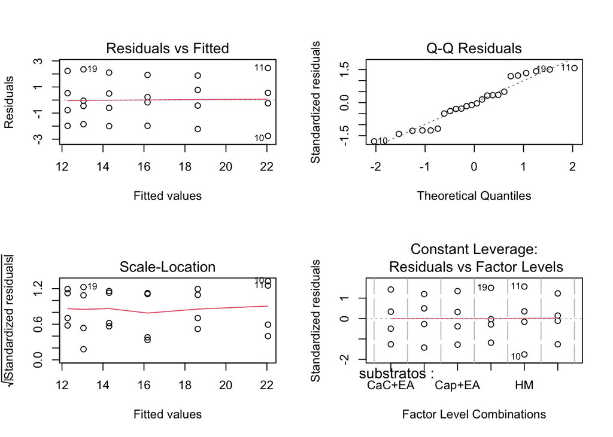

```r
par(mfrow = c(2, 2))
plot(lm_dic)
```

```r
par(mfrow = c(1, 1))
```

O mesmo procedimento deve ser repetido para o DBC e o DQL:

```r
# Exemplos para execução durante a aula:
# par(mfrow = c(2, 2))
# plot(lm_dbc)
# plot(lm_dql)
# par(mfrow = c(1, 1))
```

# Transformação de variáveis

Uma transformação substitui $Y$ por $g(Y)$ e ajusta o modelo nessa nova escala. Ela pode estabilizar variâncias, reduzir assimetria, tornar efeitos mais aditivos e diminuir a influência de valores extremos.

Transformar não corrige falta de independência, pseudorrepetição, tratamento aplicado à unidade errada, variável omitida ou delineamento inadequado. A escolha deve ter justificativa estatística e científica.

## Relação entre média e variância

Suponha que o desvio-padrão seja proporcional a uma potência da média:

$$\sigma_Y\propto\mu^\alpha.$$

Para uma transformação potência $g(Y)=Y^\lambda$, o método delta fornece, aproximadamente:

$$\operatorname{Var}[g(Y)]
\approx [g'(\mu)]^2\operatorname{Var}(Y).$$

Como $g'(\mu)=\lambda\mu^{\lambda-1}$, a variância transformada será aproximadamente constante quando:

$$\lambda=1-\alpha.$$

Esse resultado explica por que algumas transformações aparecem com frequência.

| Situação aproximada | Relação média–variância | Transformação tradicional |
| --- | --- | --- |
| variância constante | $\sigma_Y\propto 1$ | nenhuma |
| contagens de Poisson | $\sigma_Y\propto\mu^{1/2}$ | $\sqrt{Y}$ ou $\sqrt{Y+c}$ |
| erro multiplicativo/log-normal | $\sigma_Y\propto\mu$ | $\log(Y)$ |
| forte aumento da dispersão | $\sigma_Y\propto\mu^{3/2}$ | $1/\sqrt{Y}$ |
| proporção binomial | $\operatorname{Var}(P)=p(1-p)/n$ | $\arcsin(\sqrt{P})$ |

Para contagens pequenas, constantes como $3/8$ podem reduzir viés na transformação raiz. Para proporções, modelos binomiais são frequentemente mais informativos que a transformação angular, pois respeitam o número de ensaios e permitem inferência diretamente na escala de probabilidade.

## Família de Box–Cox

Para respostas estritamente positivas:

$$Y^{(\lambda)}=
\begin{cases}
\dfrac{Y^\lambda-1}{\lambda}, & \lambda\neq 0,\\[6pt]
\log(Y), & \lambda=0.
\end{cases}$$

O parâmetro $\lambda$ é escolhido pelo perfil da log-verossimilhança do modelo, incluindo o ajuste jacobiano da transformação. Valores usuais são:

- $\lambda=1$: nenhuma transformação;
- $\lambda=1/2$: raiz quadrada;
- $\lambda=0$: logaritmo;
- $\lambda=-1/2$: inverso da raiz;
- $\lambda=-1$: inverso.

Não é necessário usar mecanicamente o valor exato que maximiza o perfil. Um valor simples dentro do intervalo de confiança costuma facilitar a comunicação. Depois da escolha, o diagnóstico deve ser repetido.

## Experimento 4: dados adaptados para transformação

O exemplo do DIC foi modificado para criar assimetria e heterogeneidade mais evidentes. Essa adaptação é didática e não substitui os dados originais do Experimento 1.

Arquivo com os dados: dados_4.xlsx

```r
dados_4 <- read_xlsx("dados_4.xlsx")
dados_4$substratos <- factor(dados_4$substratos)

lm_dic2 <- lm(altura ~ substratos, data = dados_4)
anova(lm_dic2)
```

```
Analysis of Variance Table

Response: altura
           Df Sum Sq Mean Sq F value  Pr(>F)
substratos  5 275.83  55.167  3.2852 0.02783 *
Residuals  18 302.26  16.792
---
Signif. codes:  0 '***' 0.001 '**' 0.01 '*' 0.05 '.' 0.1 ' ' 1
```

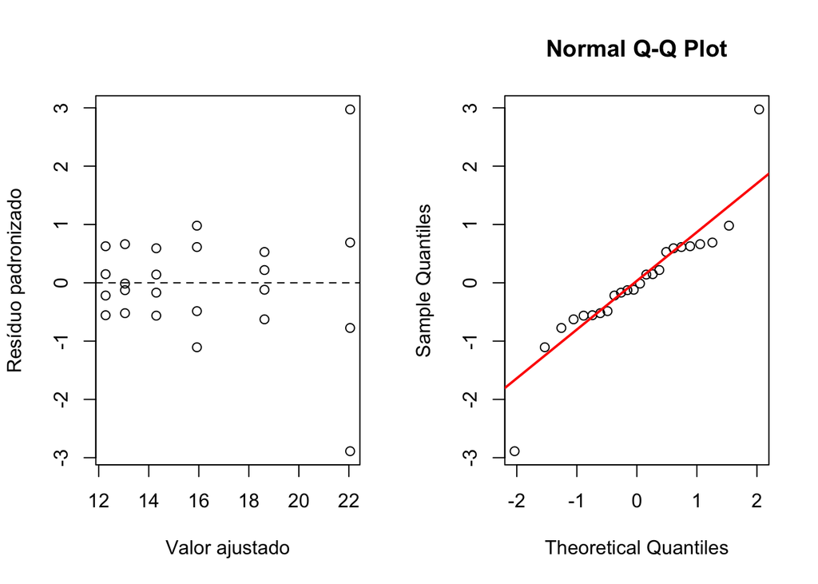

```r
par(mfrow = c(1, 2))
plot(
  fitted(lm_dic2),
  rstandard(lm_dic2),
  xlab = "Valor ajustado",
  ylab = "Resíduo padronizado"
)
abline(h = 0, lty = 2)
qqnorm(rstandard(lm_dic2))
qqline(rstandard(lm_dic2), col = "red", lwd = 2)
```

```r
par(mfrow = c(1, 1))

shapiro.test(rstandard(lm_dic2))
```

```
    Shapiro-Wilk normality test

data:  rstandard(lm_dic2)
W = 0.88827, p-value = 0.01224
```

```r
bartlett.test(altura ~ substratos, data = dados_4)
```

```
    Bartlett test of homogeneity of variances

data:  altura by substratos
Bartlett's K-squared = 14.889, df = 5, p-value = 0.01085
```

Usando a função `crd` do pacote `ExpDes`:

```r
crd(
  treat = dados_4$substratos,
  resp = dados_4$altura,
  mcomp = "tukey"
)
```

```
------------------------------------------------------------------------
Analysis of Variance Table
------------------------------------------------------------------------
           DF     SS     MS     Fc    Pr>Fc
Treatament  5 275.83 55.167 3.2852 0.027833
Residuals  18 302.26 16.792
Total      23 578.10
------------------------------------------------------------------------
CV = 25.55 %

------------------------------------------------------------------------
Shapiro-Wilk normality test
p-value:  0.01224471
WARNING: at 5% of significance, residuals can not be considered normal!
------------------------------------------------------------------------

------------------------------------------------------------------------
Homogeneity of variances test
p-value:  0.01084858
WARNING: at 5% of significance, residuals can not be considered homocedastic!
------------------------------------------------------------------------

Tukey's test
------------------------------------------------------------------------
Groups Treatments Means
a    HM      22.05
ab   CaC+EB      18.625
ab   Plantmax    15.925
ab   Cap+EA      14.3
ab   Cap+EB      13.05
 b   CaC+EA      12.275
------------------------------------------------------------------------
```

O exemplo apresenta evidências de não normalidade e de variâncias diferentes. O perfil de Box–Cox é obtido por:

```r
perfil_boxcox <- boxcox(
  lm_dic2,
  lambda = seq(-3, 3, by = 0.05),
  plotit = FALSE
)

lambda_estimado <- perfil_boxcox$x[which.max(perfil_boxcox$y)]
lambda_estimado
```

```
[1] -1.1
```

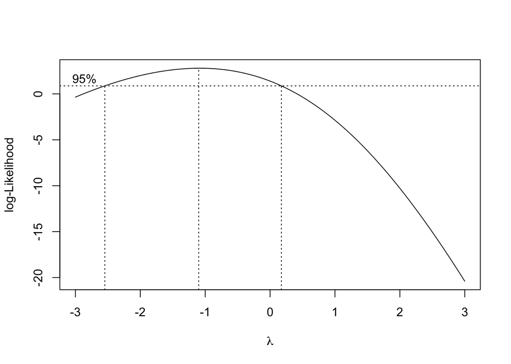

```r
boxcox(lm_dic2, lambda = seq(-3, 3, by = 0.05))
```

O máximo do perfil fica próximo de $-1{,}1$, mas o logaritmo é usado a seguir para mostrar uma transformação simples, interpretável e capaz de melhorar consideravelmente os diagnósticos. A decisão final deve considerar o perfil completo, o intervalo de confiança e o objetivo inferencial.

```r
dados_4$altura_log <- log(dados_4$altura)

lm_dic_log <- lm(altura_log ~ substratos, data = dados_4)
anova(lm_dic_log)
```

```
Analysis of Variance Table

Response: altura_log
           Df  Sum Sq  Mean Sq F value  Pr(>F)
substratos  5 0.84929 0.169858  3.4324 0.02365 *
Residuals  18 0.89075 0.049486
---
Signif. codes:  0 '***' 0.001 '**' 0.01 '*' 0.05 '.' 0.1 ' ' 1
```

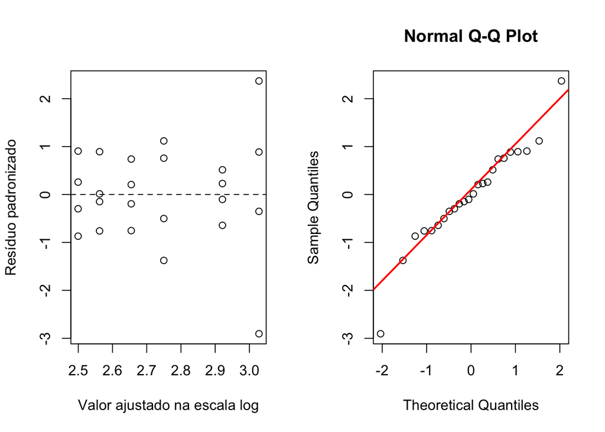

```r
par(mfrow = c(1, 2))
plot(
  fitted(lm_dic_log),
  rstandard(lm_dic_log),
  xlab = "Valor ajustado na escala log",
  ylab = "Resíduo padronizado"
)
abline(h = 0, lty = 2)
qqnorm(rstandard(lm_dic_log))
qqline(rstandard(lm_dic_log), col = "red", lwd = 2)
```

```r
par(mfrow = c(1, 1))

shapiro.test(rstandard(lm_dic_log))
```

```
    Shapiro-Wilk normality test

data:  rstandard(lm_dic_log)
W = 0.94999, p-value = 0.2708
```

```r
bartlett.test(altura_log ~ substratos, data = dados_4)
```

```
    Bartlett test of homogeneity of variances

data:  altura_log by substratos
Bartlett's K-squared = 9.2157, df = 5, p-value = 0.1008
```

No exemplo, o valor-$p$ de Shapiro–Wilk passa de aproximadamente $0{,}012$ para $0{,}271$, e o valor-$p$ de Bartlett passa de aproximadamente $0{,}011$ para $0{,}101$. Isso não prova que o modelo transformado é verdadeiro, mas mostra uma melhoria conjunta dos diagnósticos.

```r
crd(
  treat = dados_4$substratos,
  resp = dados_4$altura_log,
  mcomp = "tukey"
)
```

```
------------------------------------------------------------------------
Analysis of Variance Table
------------------------------------------------------------------------
           DF      SS       MS     Fc    Pr>Fc
Treatament  5 0.84929 0.169858 3.4324 0.023648
Residuals  18 0.89075 0.049486
Total      23 1.74004
------------------------------------------------------------------------
CV = 8.13 %

------------------------------------------------------------------------
Shapiro-Wilk normality test
p-value:  0.2708366
According to Shapiro-Wilk normality test at 5% of significance, residuals can be considered normal.
------------------------------------------------------------------------

------------------------------------------------------------------------
Homogeneity of variances test
p-value:  0.1007622
According to the test of bartlett at 5% of significance, residuals can be considered homocedastic.
------------------------------------------------------------------------

Tukey's test
------------------------------------------------------------------------
Groups Treatments Means
a    HM      3.027798
ab   CaC+EB      2.9211
ab   Plantmax    2.749833
ab   Cap+EA      2.654726
ab   Cap+EB      2.562232
 b   CaC+EA      2.499521
------------------------------------------------------------------------
```

## Interpretação e retrotransformação

Quando o modelo é ajustado a $\log(Y)$, uma diferença entre médias logarítmicas corresponde, após exponenciação, a uma **razão de médias geométricas**. Ela não é, em geral, uma diferença entre médias aritméticas na escala original.

```r
medias_log <- aggregate(
  altura_log ~ substratos,
  data = dados_4,
  FUN = mean
)

medias_log$media_geometrica <- exp(medias_log$altura_log)
medias_log
```

```
  substratos altura_log media_geometrica
1     CaC+EA   2.499521         12.17666
2     CaC+EB   2.921100         18.56170
3     Cap+EA   2.654726         14.22109
4     Cap+EB   2.562232         12.96472
5         HM   3.027798         20.65170
6   Plantmax   2.749833         15.64003
```

Como $E[\exp(X)]\neq\exp[E(X)]$, simplesmente exponenciar uma média logarítmica não estima automaticamente a média aritmética original. Para esse alvo podem ser necessárias correções de viés ou predições marginais apropriadas.

## Transformar ou mudar de modelo?

- Para contagens, considere modelos Poisson ou binomial negativo.
- Para proporções com numerador e denominador conhecidos, considere o modelo binomial.
- Para respostas positivas contínuas e assimétricas, considere modelos Gama ou log-normal.
- Para variâncias diferentes conhecidas por grupo, considere modelos com estrutura de variância.
- Para dependência entre medidas, considere modelos mistos ou modelos de correlação.

Transformações e modelos generalizados não são rivais automáticos. A escolha depende da escala em que o efeito científico deve ser interpretado e do mecanismo probabilístico plausível para a resposta.

# Testes não paramétricos

Métodos não paramétricos não são métodos sem pressupostos. Eles evitam uma forma paramétrica completa para a distribuição, mas ainda exigem independência ou pareamento correto, escala ordinal ou quantitativa e respeito ao delineamento.

Em testes por postos, observações ordenadas recebem postos $1,\ldots,N$; empates recebem o posto médio. Transformações estritamente crescentes não alteram os postos.

Testes como Kruskal–Wallis e Friedman avaliam igualdade de distribuições ou de posições relativas. A interpretação estrita como comparação de medianas requer que as distribuições tenham aproximadamente a mesma forma e dispersão.

| Estrutura dos dados | Teste paramétrico | Alternativa por postos |
| --- | --- | --- |
| dois grupos independentes | teste $t$ | Mann–Whitney–Wilcoxon |
| dois grupos pareados | teste $t$ pareado | Wilcoxon pareado |
| mais de dois grupos independentes/DIC | ANOVA de um fator | Kruskal–Wallis |
| mais de dois tratamentos em blocos/DBC | ANOVA em blocos | Friedman |
| DQL | ANOVA com linhas e colunas | não há substituto clássico único |

Nesta seção, os experimentos anteriores serão reanalisados por métodos não paramétricos **mesmo quando os pressupostos da ANOVA forem razoáveis**. A finalidade é comparar perguntas, resultados e limitações.

## Reanálise do Experimento 1: Kruskal–Wallis no DIC

Para $a$ tratamentos, $N$ observações e soma de postos $R_i$ no tratamento $i$, a estatística sem a correção de empates é:

$$H=\frac{12}{N(N+1)}
\sum_{i=1}^{a}\frac{R_i^2}{n_i}-3(N+1).$$

Sob $H_0$, usa-se aproximadamente $H\sim\chi^2_{a-1}$. O R aplica a correção necessária para empates.

Com amostras muito pequenas ou muitos empates, a aproximação qui-quadrado pode ser imprecisa. Procedimentos exatos ou de permutação são preferíveis quando disponíveis e quando reproduzem corretamente a aleatorização.

```r
kw_dados_1 <- kruskal.test(
  altura ~ substratos,
  data = dados_1
)

kw_dados_1
```

```
    Kruskal-Wallis rank sum test

data:  altura by substratos
Kruskal-Wallis chi-squared = 18.312, df = 5, p-value = 0.00258
```

O teste também detecta diferenças entre os substratos ($H=18{,}31$; valor-$p=0{,}0026$). Um tamanho de efeito descritivo é:

$$\varepsilon_H^2=
\frac{H-a+1}{N-a}.$$

```r
n_kw <- nrow(dados_1)
k_kw <- nlevels(dados_1$substratos)

epsilon2_kw <- max(
  0,
  (as.numeric(kw_dados_1$statistic) - k_kw + 1) / (n_kw - k_kw)
)

epsilon2_kw
```

```
[1] 0.739547
```

Após um teste global significativo, podem ser realizadas comparações de Wilcoxon duas a duas com ajuste de Holm:

```r
pairwise.wilcox.test(
  x = dados_1$altura,
  g = dados_1$substratos,
  p.adjust.method = "holm",
  exact = FALSE
)
```

```
    Pairwise comparisons using Wilcoxon rank sum test with continuity correction

data:  dados_1$altura and dados_1$substratos

         CaC+EA CaC+EB Cap+EA Cap+EB HM
CaC+EB   0.46   -      -      -      -
Cap+EA   0.78   0.46   -      -      -
Cap+EB   0.94   0.46   0.94   -      -
HM       0.46   0.56   0.46   0.46   -
Plantmax 0.48   0.49   0.78   0.48   0.46

P value adjustment method: holm
```

Com apenas quatro observações por substrato, as comparações individuais têm baixa resolução e nenhuma permanece significativa após o ajuste de Holm, apesar do teste global significativo. Esse resultado não é contraditório: o teste global reúne evidência de todas as diferenças, enquanto cada comparação usa menos informação e sofre correção por multiplicidade.

## Reanálise do Experimento 2: Friedman no DBC

O teste de Friedman ranqueia os $a$ tratamentos **dentro de cada bloco**. Se $R_{i\cdot}$ é a soma dos postos do tratamento $i$ nos $b$ blocos, a estatística sem empates é:

$$Q=\frac{12}{ba(a+1)}
\sum_{i=1}^{a}R_{i\cdot}^2-3b(a+1).$$

Sob $H_0$, $Q$ é comparada aproximadamente a $\chi^2_{a-1}$.

O teste requer um bloco completo: todos os tratamentos devem aparecer em todos os blocos. Observações ausentes não podem ser simplesmente descartadas sem alterar a estrutura. Empates dentro de blocos recebem postos médios e exigem a correção incorporada pela implementação do R.

```r
friedman_dados_2 <- friedman.test(
  produtividade ~ epoca | bloco,
  data = dados_2
)

friedman_dados_2
```

```
    Friedman rank sum test

data:  produtividade and epoca and bloco
Friedman chi-squared = 10.4, df = 3, p-value = 0.01545
```

O teste detecta diferenças entre épocas ($Q=10{,}40$; valor-$p=0{,}0155$), em concordância qualitativa com a ANOVA do DBC.

Os postos e suas médias podem ser examinados diretamente:

```r
dados_2$posto_no_bloco <- ave(
  dados_2$produtividade,
  dados_2$bloco,
  FUN = rank
)

aggregate(
  posto_no_bloco ~ epoca,
  data = dados_2,
  FUN = function(x) c(soma = sum(x), media = mean(x))
)
```

```
  epoca posto_no_bloco.soma posto_no_bloco.media
1     A           23.000000             3.833333
2     B            9.000000             1.500000
3     C           13.000000             2.166667
4     D           15.000000             2.500000
```

O coeficiente de concordância de Kendall associado ao teste é:

$$W=\frac{Q}{b(a-1)},\qquad 0\leq W\leq 1.$$

```r
b_friedman <- nlevels(dados_2$bloco)
a_friedman <- nlevels(dados_2$epoca)

kendall_w <- as.numeric(friedman_dados_2$statistic) /
  (b_friedman * (a_friedman - 1))

kendall_w
```

```
[1] 0.5777778
```

Para comparações posteriores, cada par deve preservar o pareamento por bloco.

```r
matriz_dbc <- xtabs(
  produtividade ~ bloco + epoca,
  data = dados_2
)

pares_epocas <- combn(colnames(matriz_dbc), 2, simplify = FALSE)

pos_friedman <- do.call(
  rbind,
  lapply(pares_epocas, function(par) {
    teste <- wilcox.test(
      matriz_dbc[, par[1]],
      matriz_dbc[, par[2]],
      paired = TRUE,
      exact = FALSE
    )

    data.frame(
      epoca_1 = par[1],
      epoca_2 = par[2],
      p_bruto = teste$p.value
    )
  })
)

pos_friedman$p_holm <- p.adjust(pos_friedman$p_bruto, method = "holm")
pos_friedman
```

```
  epoca_1 epoca_2    p_bruto    p_holm
1       A       B 0.03603169 0.2161901
2       A       C 0.05917207 0.2366883
3       A       D 0.03603169 0.2161901
4       B       C 0.20841280 0.4266397
5       B       D 0.14221324 0.4266397
6       C       D 0.52823278 0.5282328
```

Novamente, o número reduzido de blocos limita a potência das comparações pareadas com correção para multiplicidade.

## Teste de randomização restrita no DBC

Outra alternativa usa diretamente a casualização. Sob a hipótese nula forte de nenhum efeito individual de tratamento, os rótulos podem ser permutados dentro de cada bloco. A estatística escolhida será o $F$ de tratamentos.

Com $B$ permutações Monte Carlo:

$$\widehat p=
\frac{1+\sum_{s=1}^{B}I(F_s\geq F_{obs})}{B+1}.$$

```r
estatistica_f_dbc <- function(dados) {
  ajuste <- lm(produtividade ~ bloco + epoca, data = dados)
  anova(ajuste)["epoca", "F value"]
}

set.seed(2026)
B_dbc <- 4999
f_observado_dbc <- estatistica_f_dbc(dados_2)

f_permutado_dbc <- replicate(B_dbc, {
  dados_perm <- dados_2
  dados_perm$epoca <- ave(
    as.character(dados_perm$epoca),
    dados_perm$bloco,
    FUN = sample
  )
  dados_perm$epoca <- factor(
    dados_perm$epoca,
    levels = levels(dados_2$epoca)
  )
  estatistica_f_dbc(dados_perm)
})

p_randomizacao_dbc <-
  (1 + sum(f_permutado_dbc >= f_observado_dbc)) / (B_dbc + 1)

ep_monte_carlo_dbc <- sqrt(
  p_randomizacao_dbc * (1 - p_randomizacao_dbc) / (B_dbc + 1)
)

c(
  F_observado = f_observado_dbc,
  p_monte_carlo = p_randomizacao_dbc,
  erro_padrao_monte_carlo = ep_monte_carlo_dbc
)
```

```
            F_observado           p_monte_carlo erro_padrao_monte_carlo
            8.470588993             0.003200000             0.000798719
```

Permutar tratamentos livremente entre blocos seria incorreto, pois não reproduziria a casualização do DBC.

## Reanálise do Experimento 3: uma alternativa para o DQL

Não existe um teste clássico por postos que seja, ao mesmo tempo, equivalente ao Friedman e controle as duas restrições do DQL. Kruskal–Wallis ignoraria lotes e operadores; Friedman controlaria somente uma dessas fontes.

Como análise didática de sensibilidade, será usado o procedimento de Freedman–Lane:

1. ajustar o modelo reduzido com lote e operador;
2. permutar os resíduos do modelo reduzido;
3. somar os resíduos permutados aos valores ajustados;
4. reajustar o modelo completo;
5. comparar o $F$ permutado de formulações com o observado.

Esse teste não exige normalidade, mas requer que os resíduos sejam permutáveis sob a hipótese nula. Ele é uma aproximação baseada no modelo e não deve ser confundido com a reconstrução exata de todas as casualizações possíveis do quadrado latino.

Permutabilidade ainda envolve condições: os erros devem ter distribuição comparável entre as células após o ajuste dos efeitos de linha e coluna. Forte heterogeneidade ou dependência também pode invalidar esse procedimento.

```r
modelo_reduzido_dql <- lm(
  velocidade ~ lote + operador,
  data = dados_3
)

f_observado_dql <- anova(lm_dql)["formulacoes", "F value"]

set.seed(2026)
B_dql <- 4999

f_permutado_dql <- replicate(B_dql, {
  dados_perm <- dados_3
  dados_perm$velocidade <- fitted(modelo_reduzido_dql) +
    sample(residuals(modelo_reduzido_dql))

  ajuste_perm <- lm(
    velocidade ~ lote + operador + formulacoes,
    data = dados_perm
  )

  anova(ajuste_perm)["formulacoes", "F value"]
})

p_permutacao_dql <-
  (1 + sum(f_permutado_dql >= f_observado_dql)) / (B_dql + 1)

ep_monte_carlo_dql <- sqrt(
  p_permutacao_dql * (1 - p_permutacao_dql) / (B_dql + 1)
)

c(
  F_observado = f_observado_dql,
  p_monte_carlo = p_permutacao_dql,
  erro_padrao_monte_carlo = ep_monte_carlo_dql
)
```

```
            F_observado           p_monte_carlo erro_padrao_monte_carlo
            7.734375000             0.003200000             0.000798719
```

O resultado Monte Carlo fica próximo do valor-$p$ paramétrico e sustenta a conclusão de diferença entre formulações. O valor exato pode variar ligeiramente com a semente e com o número de permutações.

## Reanálise do Experimento 4: Kruskal–Wallis nos dados assimétricos

O teste de Kruskal–Wallis pode ser aplicado aos dados brutos adaptados:

```r
kw_dados_4 <- kruskal.test(
  altura ~ substratos,
  data = dados_4
)

kw_dados_4
```

```
    Kruskal-Wallis rank sum test

data:  altura by substratos
Kruskal-Wallis chi-squared = 10.602, df = 5, p-value = 0.05987
```

Neste caso, a ANOVA bruta produz valor-$p\approx0{,}028$, enquanto o teste de Kruskal–Wallis produz valor-$p\approx0{,}060$. A diferença é didaticamente importante: testes paramétricos, transformações e testes por postos não respondem exatamente à mesma hipótese e atribuem pesos diferentes às magnitudes e aos valores extremos. Não se deve escolher o método apenas porque ele produz o menor valor-$p$.

## Comparação das estratégias

| Estratégia | Usa magnitudes? | Normalidade dos erros? | Respeita o delineamento? | Interpretação principal |
| --- | --- | --- | --- | --- |
| ANOVA clássica | sim | para inferência exata pequena | sim | médias |
| ANOVA transformada | sim, em nova escala | aproximadamente | sim | médias transformadas |
| Kruskal–Wallis | somente ordem | não | somente grupos independentes | distribuições/postos |
| Friedman | postos intrablocos | não | DBC completo | distribuições/postos em blocos |
| randomização/permutação | depende da estatística | não | sim, se corretamente restrita | hipótese definida pela permutação |
| modelo generalizado | sim | não para a resposta bruta | sim, se bem especificado | média via função de ligação |

O método não paramétrico não é automaticamente superior quando a normalidade é questionável. O desenho experimental, a pergunta científica e a escala de interpretação continuam sendo centrais.

# Introdução aos experimentos fatoriais

Um experimento fatorial estuda dois ou mais fatores simultaneamente. Ele não é, por si só, um delineamento: é uma **estrutura de tratamentos**. As combinações fatoriais podem ser distribuídas em DIC, DBC, quadrado latino ou outro delineamento adequado.

Em um fatorial completo, todas as combinações dos níveis dos fatores são observadas. Se o fator $A$ tem $a$ níveis e o fator $B$ tem $b$ níveis, existem:

$$a\times b$$

combinações de tratamentos. Com $r$ repetições por combinação, o número total de unidades é:

$$N=abr.$$

Os fatores são **cruzados** porque cada nível de $A$ ocorre com cada nível de $B$. Isso é diferente de fatores aninhados, nos quais os níveis de um fator existem apenas dentro de um nível específico do outro.

## Por que usar um fatorial?

- Estimar os efeitos de vários fatores em um único experimento.
- Usar as observações de todas as combinações para estimar efeitos principais.
- Investigar interação entre fatores.
- Produzir conclusões mais amplas do que experimentos separados de um fator.
- Identificar combinações de níveis que funcionam de maneira particular.

A principal informação adicional é a **interação**. Há interação quando o efeito de um fator depende do nível do outro.

Se $\mu_{ij}$ é a média no nível $i$ de $A$ e no nível $j$ de $B$, a ausência de interação implica que diferenças entre níveis de $A$ são constantes nos níveis de $B$. Para dois níveis $i$ e $i'$ de $A$:

$$\mu_{ij}-\mu_{i'j}
=
\mu_{ij'}-\mu_{i'j'}.$$

Graficamente, perfis aproximadamente paralelos indicam pouca interação; linhas não paralelas sugerem interação. O gráfico é diagnóstico e descritivo: a decisão inferencial vem do modelo.

## Fatorial $3\times2$

Considere dois fatores:

- fator $A$: recipiente, com três níveis ($R_1$, $R_2$ e $R_3$);
- fator $B$: espécie, com dois níveis ($E_1$ e $E_2$).

O experimento tem $3\times2=6$ combinações de tratamentos. Com quatro repetições por combinação, são necessárias $3\times2\times4=24$ unidades experimentais.

Em um DIC, o modelo é:

$$Y_{ijk}
=
\mu+\alpha_i+\beta_j+(\alpha\beta)_{ij}+\varepsilon_{ijk},$$

em que:

- $\alpha_i$ é o efeito do nível $i$ do recipiente;
- $\beta_j$ é o efeito do nível $j$ da espécie;
- $(\alpha\beta)_{ij}$ é a interação recipiente $\times$ espécie;
- $k=1,\ldots,r$ identifica a repetição.

Restrições usuais são:

$$\sum_i\alpha_i=0,\qquad
\sum_j\beta_j=0,$$

$$\sum_i(\alpha\beta)_{ij}=0
\quad\text{para cada }j,
\qquad
\sum_j(\alpha\beta)_{ij}=0
\quad\text{para cada }i.$$

## Hipóteses e graus de liberdade

Para o fator $A$:

$$H_{0A}:\alpha_1=\alpha_2=\alpha_3=0.$$

Para o fator $B$:

$$H_{0B}:\beta_1=\beta_2=0.$$

Para a interação:

$$H_{0AB}:(\alpha\beta)_{ij}=0
\quad\text{para todos }i,j.$$

| Fonte de variação | Graus de liberdade no $3\times2$ | Estatística $F$ |
| --- | --- | --- |
| Recipiente ($A$) | $3-1=2$ | $QM_A/QM_E$ |
| Espécie ($B$) | $2-1=1$ | $QM_B/QM_E$ |
| $A\times B$ | $(3-1)(2-1)=2$ | $QM_{AB}/QM_E$ |
| Erro | $3\cdot2\cdot(4-1)=18$ |  |
| Total | $24-1=23$ |  |

A soma de quadrados das seis combinações é decomposta ortogonalmente, no caso balanceado, em:

$$SQ_{Tratamentos}=SQ_A+SQ_B+SQ_{AB}.$$

O teste da interação deve ser interpretado primeiro. Se a interação é importante, os efeitos principais são médias de comportamentos diferentes e podem esconder a relação científica relevante. Nesse caso, estudam-se os **efeitos simples**: o efeito de $A$ dentro de cada nível de $B$, ou o efeito de $B$ dentro de cada nível de $A$.

## Planejamento e casualização do fatorial

As seis combinações devem ser tratadas como condições experimentais distintas e casualizadas às 24 unidades. Cada repetição precisa ser uma unidade independente; medir quatro folhas da mesma planta não cria quatro repetições do tratamento.

```r
set.seed(2026)

combinacoes <- interaction(
  rep(c("R1", "R2", "R3"), each = 2),
  rep(c("E1", "E2"), times = 3),
  sep = ":"
)

plano_fatorial <- data.frame(
  unidade = 1:24,
  tratamento = sample(rep(as.character(combinacoes), each = 4))
)

plano_fatorial
```

```
   unidade tratamento
1        1      R1:E1
2        2      R1:E2
3        3      R2:E2
4        4      R2:E2
5        5      R2:E1
6        6      R1:E1
7        7      R2:E2
8        8      R1:E2
9        9      R3:E2
10      10      R3:E1
11      11      R2:E1
12      12      R1:E1
13      13      R1:E2
14      14      R1:E1
15      15      R3:E2
16      16      R3:E2
17      17      R3:E2
18      18      R2:E1
19      19      R3:E1
20      20      R3:E1
21      21      R2:E2
22      22      R3:E1
23      23      R1:E2
24      24      R2:E1
```

```r
table(plano_fatorial$tratamento)
```

```
R1:E1 R1:E2 R2:E1 R2:E2 R3:E1 R3:E2
    4     4     4     4     4     4
```

## Exemplo: recipientes e espécies de eucalipto

O exemplo, adaptado do material de experimentação agrícola disponível no diretório, avalia três recipientes para produção de mudas e duas espécies de eucalipto. A resposta é a altura das mudas, em cm, aos 80 dias.

- $R_1$: saco plástico pequeno;
- $R_2$: saco plástico grande;
- $R_3$: recipiente laminado;
- $E_1$: *Eucalyptus citriodora*;
- $E_2$: *Eucalyptus grandis*.

| Combinação | Rep. 1 | Rep. 2 | Rep. 3 | Rep. 4 |
| --- | --- | --- | --- | --- |
| $R_1E_1$ | 26,2 | 26,0 | 25,0 | 25,4 |
| $R_1E_2$ | 24,8 | 24,6 | 26,7 | 25,2 |
| $R_2E_1$ | 25,7 | 26,3 | 25,1 | 26,4 |
| $R_2E_2$ | 19,6 | 21,1 | 19,0 | 18,6 |
| $R_3E_1$ | 22,8 | 19,4 | 18,8 | 19,2 |
| $R_3E_2$ | 19,8 | 21,4 | 22,8 | 21,3 |

```r
recipiente <- factor(rep(c("R1", "R2", "R3"), each = 8))
especie <- factor(rep(rep(c("E1", "E2"), each = 4), times = 3))
repeticao <- factor(rep(1:4, times = 6))

altura_muda <- c(
  26.2, 26.0, 25.0, 25.4,
  24.8, 24.6, 26.7, 25.2,
  25.7, 26.3, 25.1, 26.4,
  19.6, 21.1, 19.0, 18.6,
  22.8, 19.4, 18.8, 19.2,
  19.8, 21.4, 22.8, 21.3
)

dados_fatorial <- data.frame(
  repeticao,
  recipiente,
  especie,
  altura_muda
)

writexl::write_xlsx(dados_fatorial, "dados_fatorial_3x2.xlsx")
head(dados_fatorial)
```

```
  repeticao recipiente especie altura_muda
1         1         R1      E1        26.2
2         2         R1      E1        26.0
3         3         R1      E1        25.0
4         4         R1      E1        25.4
5         1         R1      E2        24.8
6         2         R1      E2        24.6
```

```r
# Conferir as quatro repetições de cada combinação
xtabs(~ recipiente + especie, data = dados_fatorial)
```

```
          especie
recipiente E1 E2
        R1  4  4
        R2  4  4
        R3  4  4
```

Arquivo com os dados: dados_fatorial_3x2.xlsx

## Exploração das médias e da interação

```r
medias_fatoriais <- with(
  dados_fatorial,
  tapply(altura_muda, list(recipiente, especie), mean)
)

medias_fatoriais
```

```
       E1     E2
R1 25.650 25.325
R2 25.875 19.575
R3 20.050 21.325
```

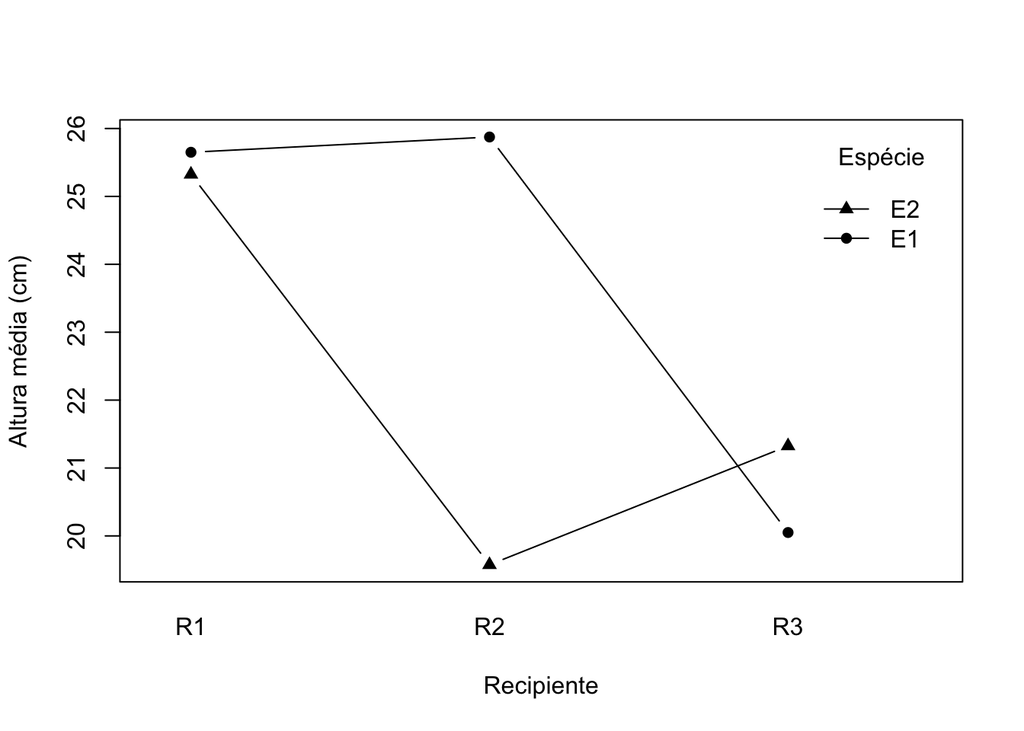

```r
with(
  dados_fatorial,
  interaction.plot(
    x.factor = recipiente,
    trace.factor = especie,
    response = altura_muda,
    type = "b",
    pch = c(16, 17),
    lty = 1,
    xlab = "Recipiente",
    ylab = "Altura média (cm)",
    trace.label = "Espécie"
  )
)
```

Os perfis não são paralelos. Em $R_1$, as espécies têm médias semelhantes; em $R_2$, $E_1$ apresenta altura muito maior que $E_2$; em $R_3$, a diferença muda de direção e é menor. Esse padrão sugere interação.

## Ajuste do modelo fatorial no R

O operador `*` inclui os dois efeitos principais e a interação:

```r
lm_fatorial <- lm(
  altura_muda ~ recipiente * especie,
  data = dados_fatorial
)

summary(lm_fatorial)
```

```
Call:
lm(formula = altura_muda ~ recipiente * especie, data = dados_fatorial)

Residuals:
    Min      1Q  Median      3Q     Max
-1.5250 -0.6687 -0.1500  0.4500  2.7500

Coefficients:
                       Estimate Std. Error t value Pr(>|t|)
(Intercept)             25.6500     0.5663  45.294  < 2e-16 ***
recipienteR2             0.2250     0.8009   0.281    0.782
recipienteR3            -5.6000     0.8009  -6.992 1.58e-06 ***
especieE2               -0.3250     0.8009  -0.406    0.690
recipienteR2:especieE2  -5.9750     1.1326  -5.275 5.13e-05 ***
recipienteR3:especieE2   1.6000     1.1326   1.413    0.175
---
Signif. codes:  0 '***' 0.001 '**' 0.01 '*' 0.05 '.' 0.1 ' ' 1

Residual standard error: 1.133 on 18 degrees of freedom
Multiple R-squared:  0.8838,    Adjusted R-squared:  0.8516
F-statistic: 27.39 on 5 and 18 DF,  p-value: 8.043e-08
```

```r
anova_fatorial <- anova(lm_fatorial)
anova_fatorial
```

```
Analysis of Variance Table

Response: altura_muda
                   Df Sum Sq Mean Sq F value    Pr(>F)
recipiente          2 92.861  46.430  36.195 4.924e-07 ***
especie             1 19.082  19.082  14.875  0.001155 **
recipiente:especie  2 63.761  31.880  24.853 6.635e-06 ***
Residuals          18 23.090   1.283
---
Signif. codes:  0 '***' 0.001 '**' 0.01 '*' 0.05 '.' 0.1 ' ' 1
```

Os três testes são significativos, inclusive a interação ($F=24{,}85$; valor-$p<0{,}001$). Portanto, a interpretação deve se concentrar nos efeitos simples, e não apenas nas médias marginais de recipientes e espécies.

Medidas de tamanho de efeito parcial podem ser calculadas por:

$$\eta_p^2=\frac{SQ_{efeito}}{SQ_{efeito}+SQ_E}.$$

```r
sq_erro_fatorial <- anova_fatorial["Residuals", "Sum Sq"]

eta2_parcial <- data.frame(
  efeito = rownames(anova_fatorial)[1:3],
  eta2_parcial = anova_fatorial[1:3, "Sum Sq"] /
    (anova_fatorial[1:3, "Sum Sq"] + sq_erro_fatorial)
)

eta2_parcial
```

```
              efeito eta2_parcial
1         recipiente    0.8008639
2            especie    0.4524760
3 recipiente:especie    0.7341419
```

## Desdobramento da interação

Para manter o mesmo quadrado médio residual do experimento completo, os efeitos simples serão calculados usando $QM_E$ e os 18 graus de liberdade residuais do modelo fatorial.

```r
qm_erro_fatorial <- anova_fatorial["Residuals", "Mean Sq"]
gl_erro_fatorial <- anova_fatorial["Residuals", "Df"]

teste_efeito_simples <- function(dados, resposta, fator) {
  y <- dados[[resposta]]
  g <- droplevels(dados[[fator]])
  medias <- tapply(y, g, mean)
  tamanhos <- table(g)
  sq <- sum(tamanhos * (medias - mean(y))^2)
  gl <- nlevels(g) - 1
  f <- (sq / gl) / qm_erro_fatorial

  c(
    SQ = sq,
    gl = gl,
    F = f,
    p_valor = pf(f, gl, gl_erro_fatorial, lower.tail = FALSE)
  )
}
```

### Efeito de espécie dentro de cada recipiente

```r
efeito_especie_em_recipiente <- do.call(
  rbind,
  lapply(levels(dados_fatorial$recipiente), function(nivel) {
    resultado <- teste_efeito_simples(
      subset(dados_fatorial, recipiente == nivel),
      resposta = "altura_muda",
      fator = "especie"
    )

    data.frame(recipiente = nivel, t(resultado))
  })
)

efeito_especie_em_recipiente$p_holm <- p.adjust(
  efeito_especie_em_recipiente$p_valor,
  method = "holm"
)

efeito_especie_em_recipiente
```

```
  recipiente       SQ gl          F      p_valor       p_holm
1         R1  0.21125  1  0.1646817 6.896656e-01 6.896656e-01
2         R2 79.38000  1 61.8813339 3.112001e-07 9.336003e-07
3         R3  3.25125  1  2.5345388 1.287883e-01 2.575765e-01
```

A diferença entre espécies é pronunciada no recipiente $R_2$. Em $R_1$ e $R_3$, as evidências são insuficientes para afirmar diferença entre espécies ao nível de $5\%$.

### Efeito de recipiente dentro de cada espécie

```r
efeito_recipiente_em_especie <- do.call(
  rbind,
  lapply(levels(dados_fatorial$especie), function(nivel) {
    resultado <- teste_efeito_simples(
      subset(dados_fatorial, especie == nivel),
      resposta = "altura_muda",
      fator = "recipiente"
    )

    data.frame(especie = nivel, t(resultado))
  })
)

efeito_recipiente_em_especie$p_holm <- p.adjust(
  efeito_recipiente_em_especie$p_valor,
  method = "holm"
)

efeito_recipiente_em_especie
```

```
  especie       SQ gl        F      p_valor       p_holm
1      E1 87.12167  2 33.95821 7.776197e-07 1.555239e-06
2      E2 69.50000  2 27.08965 3.730256e-06 3.730256e-06
```

Há diferenças entre recipientes nas duas espécies. Para investigar quais combinações diferem, pode-se comparar as seis médias de tratamento usando o mesmo erro do experimento:

```r
dados_fatorial$combinacao <- interaction(
  dados_fatorial$recipiente,
  dados_fatorial$especie,
  sep = ":"
)

aov_combinacoes <- aov(
  altura_muda ~ combinacao,
  data = dados_fatorial
)

TukeyHSD(aov_combinacoes, "combinacao", conf.level = 1 - alfa)
```

```
  Tukey multiple comparisons of means
    95% family-wise confidence level

Fit: aov(formula = altura_muda ~ combinacao, data = dados_fatorial)

$combinacao
              diff        lwr       upr     p adj
R2:E1-R1:E1  0.225 -2.3201851  2.770185 0.9997185
R3:E1-R1:E1 -5.600 -8.1451851 -3.054815 0.0000204
R1:E2-R1:E1 -0.325 -2.8701851  2.220185 0.9983324
R2:E2-R1:E1 -6.075 -8.6201851 -3.529815 0.0000068
R3:E2-R1:E1 -4.325 -6.8701851 -1.779815 0.0004825
R3:E1-R2:E1 -5.825 -8.3701851 -3.279815 0.0000120
R1:E2-R2:E1 -0.550 -3.0951851  1.995185 0.9811892
R2:E2-R2:E1 -6.300 -8.8451851 -3.754815 0.0000041
R3:E2-R2:E1 -4.550 -7.0951851 -2.004815 0.0002705
R1:E2-R3:E1  5.275  2.7298149  7.820185 0.0000444
R2:E2-R3:E1 -0.475 -3.0201851  2.070185 0.9902110
R3:E2-R3:E1  1.275 -1.2701851  3.820185 0.6135909
R2:E2-R1:E2 -5.750 -8.2951851 -3.204815 0.0000143
R3:E2-R1:E2 -4.000 -6.5451851 -1.454815 0.0011258
R3:E2-R2:E2  1.750 -0.7951851  4.295185 0.2914242
```

Essa comparação de todas as 15 diferenças é válida no DIC balanceado, mas pode ser mais ampla que a pergunta científica. Quando a interação é significativa, comparações planejadas de efeitos simples, com controle explícito de multiplicidade, costumam ser mais informativas.

## Diagnóstico do modelo fatorial

Os mesmos pressupostos do modelo linear devem ser verificados.

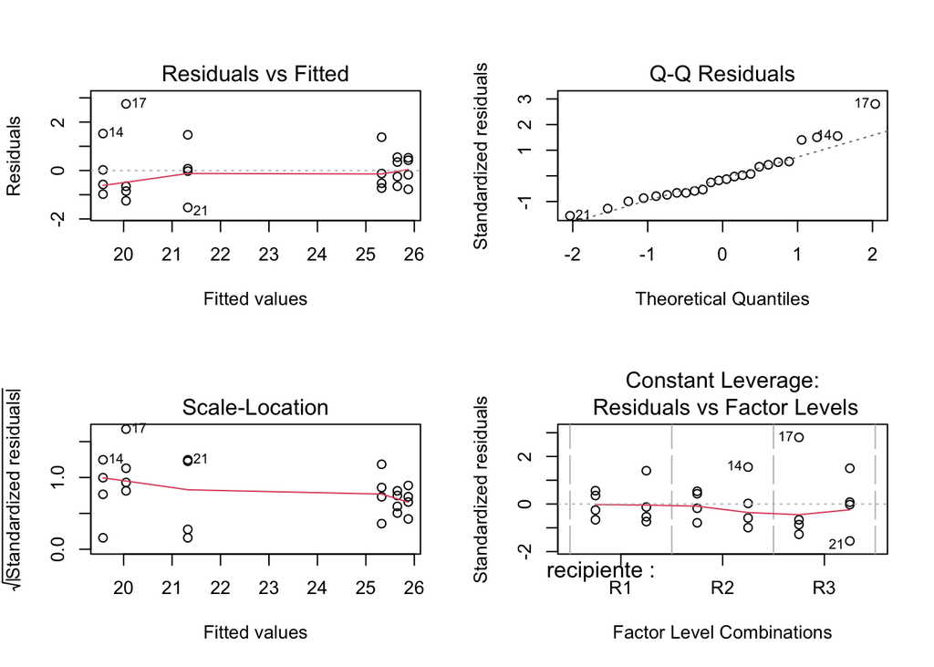

```r
par(mfrow = c(2, 2))
plot(lm_fatorial)
```

```r
par(mfrow = c(1, 1))

shapiro.test(rstandard(lm_fatorial))
```

```
    Shapiro-Wilk normality test

data:  rstandard(lm_fatorial)
W = 0.9293, p-value = 0.09402
```

Também é importante verificar a dispersão nas seis combinações. Com apenas quatro repetições por célula, testes formais têm pouca potência; o gráfico e o conhecimento do processo devem receber grande peso.

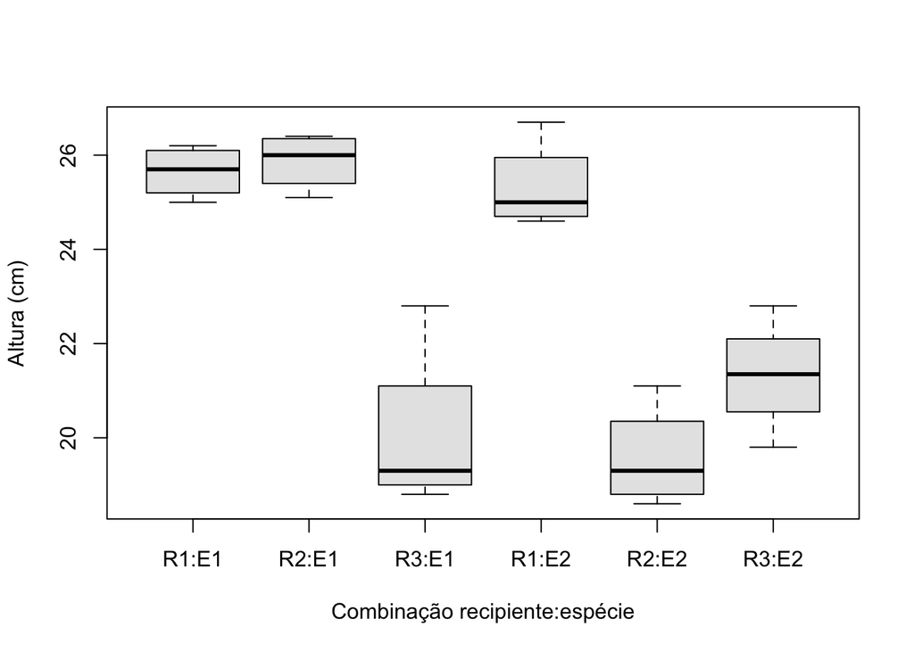

```r
boxplot(
  altura_muda ~ combinacao,
  data = dados_fatorial,
  xlab = "Combinação recipiente:espécie",
  ylab = "Altura (cm)",
  col = "gray90"
)
```

## Como interpretar uma interação

Uma sequência segura é:

1. examinar o teste e o gráfico da interação;
2. se a interação for relevante, estimar efeitos simples;
3. apresentar médias, diferenças, intervalos de confiança e unidades;
4. controlar a multiplicidade das comparações não planejadas;
5. evitar uma conclusão geral sobre um fator quando seu efeito muda com o outro.

Neste exemplo, não é adequado afirmar apenas que “$R_1$ é o melhor recipiente” ou que “$E_1$ é a melhor espécie”. A conclusão correta descreve as combinações: $R_1$ produz alturas semelhantes para as duas espécies; $R_2$ favorece fortemente $E_1$; e $R_3$ apresenta médias menores, com diferença pequena entre as espécies.

## E se o fatorial for instalado em blocos?

Se houver uma fonte de heterogeneidade, as seis combinações podem ser casualizadas dentro de cada bloco. O modelo passa a incluir o efeito de bloco:

$$Y_{ijk\ell}
=\mu+\rho_\ell+\alpha_i+\beta_j
+(\alpha\beta)_{ij}+\varepsilon_{ijk\ell}.$$

No R:

```r
# Estrutura geral para um fatorial 3 x 2 em DBC:
# lm(resposta ~ bloco + fator_A * fator_B, data = dados)
```

Os tratamentos continuam sendo as seis combinações. A casualização deve ocorrer separadamente em cada bloco, e cada bloco deve conter todas as combinações.

# Síntese do procedimento de análise

Para qualquer experimento deste material:

1. identifique unidade experimental, tratamentos, repetições e restrições de casualização;
2. organize os dados no formato longo, uma linha por unidade experimental;
3. declare tratamentos, blocos, linhas e colunas como fatores;
4. faça a exploração gráfica e descritiva sem substituir a inferência;
5. ajuste o modelo correspondente ao delineamento;
6. interprete primeiro o teste global ou a interação;
7. verifique resíduos, variâncias, independência e observações influentes;
8. use comparações múltiplas coerentes com a pergunta;
9. considere transformação, GLM ou teste não paramétrico quando justificado;
10. relate estimativas, incerteza, unidades e relevância prática.

# Erros frequentes

- Confundir subamostras com repetições independentes.
- Ignorar blocos, linhas ou colunas na análise.
- Testar normalidade dos dados brutos em vez dos resíduos.
- Escolher o pós-teste depois de observar qual fornece mais diferenças.
- Aplicar Kruskal–Wallis a dados blocados.
- Aplicar Friedman ao DQL ignorando uma das duas restrições.
- Transformar os dados sem repetir o diagnóstico.
- Retrotransformar médias sem esclarecer o alvo inferencial.
- Interpretar efeitos principais isoladamente quando há interação importante.
- Excluir outliers apenas porque ultrapassaram uma regra numérica.
- Relatar somente valor-$p$, sem médias, diferenças ou unidades.

# Modelo de relato

Um relato adequado deve indicar:

- delineamento e unidade experimental;
- fatores, níveis, número de repetições e método de casualização;
- modelo estatístico e estrutura de erro;
- diagnóstico dos pressupostos e eventuais adaptações;
- estatística, graus de liberdade e valor-$p$;
- médias ou contrastes com medida de incerteza;
- método de ajuste para multiplicidade;
- escala de análise e forma de retrotransformação, quando aplicável;
- conclusão científica, sem transformar ausência de evidência em prova de igualdade.

[@profjulianobortolini](https://instagram.com/profjulianobortolini) www.julianobortolini.com.br [linkedin](https://linkedin.com/in/julianobortolini) [github](https://github.com/julianobortolini) [lattes](http://lattes.cnpq.br/6210909768845403)